# FRA_NitinYadav

Nitin Yadav

14/02/2020

## Business Problem

We have been given the data for various companies in terms of financial information which includes Assets, Capital, Income, Sales and key financial ratios. Based on the Networth “Next Year” we have to build a predictive model to identify if the company will default next year or not. We will use the Logistic regression model to build the model and check the model performance on the Test set for the accuracy.

## Outlier and Missing value Treatment

Also we notice that there are lot of NA values present in the dataset,almost in many of the columns , so we will treat the NA values.

We have option to do the imputation using mean, median or using the MICE package. We will not use Mice package as couple of variable names in the dataset have space in between them, hence the other preferred method is KNN imputation which will use the nearby variables to calculate the imputation value.

We will also take the variables of interest in our dataset and the final dataset after treating for outliers and missing value. The final dataset consist of 3302 entries and 22 columns. The test data has 670 entries and 22 columns

## New Variable creations

We will create the below new variables to be included in the dataset. Liquidity ratio are already calculated as part of dataset, so we will not crete variables for liquidity.

Profitability

1 . Return on Asset 2. Return on Equity

Leverage

1. Debt to Equity ratio - This ratio already given as part of dataset
2. Debt to Capital ratio

Liquidity Ratio

1. Current Ratio - given as part of dataset
2. Quick Ratio - given as part of dataset
3. Cash ratio - given as part of dataset

Company Size Ratio

1. Income to Sales Ratio
2. Profit to Sales Ratio
3. Profit to Income Ratio

## Multicolinearity Analysis

We notice that the financial ratios have been derived from the individual variables , hence if we check the correlation plot , we will surely notice the collinearity among variables,so we will build the logistic regression model and after that we will check multicolinearity using VIF and will also create a correlation plot.

The same has been covered as part of LR model building

```r
library(readxl)
library(dplyr)
```

```r
library(corrplot)
library(mice)
library(DMwR)
library(car)
library(caret)
library(SDMTools)
library(lattice)

Tr_D=read_excel("raw-data.xlsx")





dim(Tr_D)
```

```
## [1] 3541   52
```

```r
summary(Tr_D)
```

```
##       Num       Networth Next Year  Total assets         Net worth
##  Min.   :   1   Min.   :-74265.6   Min.   :      0.1   Min.   :     0.0
##  1st Qu.: 886   1st Qu.:    31.7   1st Qu.:     91.3   1st Qu.:    31.3
##  Median :1773   Median :   116.3   Median :    309.7   Median :   102.3
##  Mean   :1772   Mean   :  1616.3   Mean   :   3443.4   Mean   :  1295.9
##  3rd Qu.:2658   3rd Qu.:   456.1   3rd Qu.:   1098.7   3rd Qu.:   377.3
##  Max.   :3545   Max.   :805773.4   Max.   :1176509.2   Max.   :613151.6
##
##   Total income       Change in stock    Total expenses
##  Min.   :      0.0   Min.   :-3029.40   Min.   :     -0.1
##  1st Qu.:    106.5   1st Qu.:   -1.80   1st Qu.:     95.8
##  Median :    444.9   Median :    1.60   Median :    407.7
##  Mean   :   4582.8   Mean   :   41.49   Mean   :   4262.9
##  3rd Qu.:   1440.9   3rd Qu.:   18.05   3rd Qu.:   1359.8
##  Max.   :2442828.2   Max.   :14185.50   Max.   :2366035.3
##  NA's   :198         NA's   :458        NA's   :139
##  Profit after tax        PBDITA              PBT
##  Min.   : -3908.30   Min.   :  -440.7   Min.   : -3894.80
##  1st Qu.:     0.50   1st Qu.:     6.9   1st Qu.:     0.70
##  Median :     8.80   Median :    35.4   Median :    12.40
##  Mean   :   277.36   Mean   :   578.1   Mean   :   383.81
##  3rd Qu.:    52.27   3rd Qu.:   150.2   3rd Qu.:    71.97
##  Max.   :119439.10   Max.   :208576.5   Max.   :145292.60
##  NA's   :131         NA's   :131        NA's   :131
##   Cash profit        PBDITA as % of total income PBT as % of total income
##  Min.   : -2245.70   Min.   :-6400.000           Min.   :-21340.00
##  1st Qu.:     2.90   1st Qu.:    5.000           1st Qu.:     0.55
##  Median :    18.85   Median :    9.660           Median :     3.31
##  Mean   :   392.07   Mean   :    4.571           Mean   :   -17.28
##  3rd Qu.:    93.20   3rd Qu.:   16.390           3rd Qu.:     8.80
##  Max.   :176911.80   Max.   :  100.000           Max.   :   100.00
##  NA's   :131         NA's   :68                  NA's   :68
##  PAT as % of total income Cash profit as % of total income
##  Min.   :-21340.00        Min.   :-15020.000
##  1st Qu.:     0.35        1st Qu.:     2.020
##  Median :     2.34        Median :     5.640
##  Mean   :   -19.20        Mean   :    -8.229
##  3rd Qu.:     6.34        3rd Qu.:    10.700
##  Max.   :   150.00        Max.   :   100.000
##  NA's   :68               NA's   :68
```

[output cut: 105 more lines]

```
##  Min.   :-843181.8   Min.   :-843181.8   Min.   :      0.1
##  1st Qu.:      0.0   1st Qu.:      0.0   1st Qu.:     91.3
##  Median :      1.4   Median :      1.2   Median :    309.7
##  Mean   :   -220.3   Mean   :   -221.5   Mean   :   3443.4
##  3rd Qu.:      9.6   3rd Qu.:      7.5   3rd Qu.:   1098.7
##  Max.   :  34522.5   Max.   :  34522.5   Max.   :1176509.2
##
##   PE on BSE
##  Length:3541
##  Class :character
##  Mode  :character
##
##
##
##
```

```r
str(Tr_D)
```

```
## Classes 'tbl_df', 'tbl' and 'data.frame':    3541 obs. of  52 variables:
##  $ Num                                        : num  1 2 3 4 5 6 7 8 9 10 ...
##  $ Networth Next Year                         : num  8890.6 394.3 92.2 2.7 109 ...
##  $ Total assets                               : num  17512.3 941 232.8 2.7 478.5 ...
##  $ Net worth                                  : num  7093.2 351.5 100.6 2.7 107.6 ...
##  $ Total income                               : num  24965 1527 477 NA 1580 ...
##  $ Change in stock                            : num  235.8 42.7 -5.2 NA -17 ...
##  $ Total expenses                             : num  23658 1455 479 NA 1558 ...
##  $ Profit after tax                           : num  1543.2 115.2 -6.6 NA 5.5 ...
##  $ PBDITA                                     : num  2860.2 283 5.8 NA 31 ...
##  $ PBT                                        : num  2417.2 188.4 -6.6 NA 6.3 ...
##  $ Cash profit                                : num  1872.8 158.6 0.3 NA 11.9 ...
##  $ PBDITA as % of total income                : num  11.46 18.53 1.22 0 1.96 ...
##  $ PBT as % of total income                   : num  9.68 12.33 -1.38 0 0.4 ...
##  $ PAT as % of total income                   : num  6.18 7.54 -1.38 0 0.35 2.81 0 0.72 8.29 -2.88 ...
```

[output cut: 38 more lines]

```r
Tr_D$Default=ifelse(Tr_D$`Networth Next Year`>0,0,1)
Tr_D$Default=as.factor(Tr_D$Default)

# Check for NA values

sum(is.na(Tr_D))
```

```
## [1] 13548
```

```r
colSums(is.na(Tr_D))
```

```
##                                         Num
##                                           0
##                          Networth Next Year
##                                           0
##                                Total assets
##                                           0
##                                   Net worth
##                                           0
##                                Total income
##                                         198
##                             Change in stock
##                                         458
##                              Total expenses
##                                         139
##                            Profit after tax
##                                         131
##                                      PBDITA
##                                         131
##                                         PBT
##                                         131
##                                 Cash profit
##                                         131
##                 PBDITA as % of total income
##                                          68
##                    PBT as % of total income
##                                          68
##                    PAT as % of total income
##                                          68
##            Cash profit as % of total income
##                                          68
##                       PAT as % of net worth
##                                           0
##                                       Sales
##                                         259
##              Income from financial services
##                                         935
##                                Other income
##                                        1295
##                               Total capital
##                                           4
```

[output cut: 51 more lines]

```
##                                          75
##                          Shares outstanding
##                                           0
##                           Equity face value
##                                           0
##                                         EPS
##                                           0
##                                Adjusted EPS
##                                           0
##                           Total liabilities
##                                           0
##                                   PE on BSE
##                                          23
##                                     Default
##                                           0
```

```r
# Take the variables of interest in data drame and exclude other variables not required

dim(Tr_D)
```

```
## [1] 3541   53
```

```r
Tr_D1=Tr_D[,c(3:5,8,11,17,20,23,24,36:40,51,53)]

dim(Tr_D1)
```

```
## [1] 3541   16
```

```r
summary(Tr_D1)
```

```
##   Total assets         Net worth         Total income
##  Min.   :      0.1   Min.   :     0.0   Min.   :      0.0
##  1st Qu.:     91.3   1st Qu.:    31.3   1st Qu.:    106.5
##  Median :    309.7   Median :   102.3   Median :    444.9
##  Mean   :   3443.4   Mean   :  1295.9   Mean   :   4582.8
##  3rd Qu.:   1098.7   3rd Qu.:   377.3   3rd Qu.:   1440.9
##  Max.   :1176509.2   Max.   :613151.6   Max.   :2442828.2
##                                         NA's   :198
##  Profit after tax     Cash profit            Sales
##  Min.   : -3908.30   Min.   : -2245.70   Min.   :      0.1
##  1st Qu.:     0.50   1st Qu.:     2.90   1st Qu.:    112.7
##  Median :     8.80   Median :    18.85   Median :    453.1
##  Mean   :   277.36   Mean   :   392.07   Mean   :   4549.5
##  3rd Qu.:    52.27   3rd Qu.:    93.20   3rd Qu.:   1433.5
##  Max.   :119439.10   Max.   :176911.80   Max.   :2384984.4
##  NA's   :131         NA's   :131         NA's   :259
##  Total capital       Borrowings        Current liabilities & provisions
##  Min.   :    0.1   Min.   :     0.10   Min.   :     0.1
##  1st Qu.:   13.1   1st Qu.:    23.95   1st Qu.:    17.8
##  Median :   42.1   Median :    99.20   Median :    69.4
##  Mean   :  216.6   Mean   :  1122.28   Mean   :   940.6
##  3rd Qu.:  100.3   3rd Qu.:   352.60   3rd Qu.:   261.7
##  Max.   :78273.2   Max.   :278257.30   Max.   :352240.3
##  NA's   :4         NA's   :366         NA's   :96
##  Net working capital Quick ratio (times) Current ratio (times)
##  Min.   :-63839.0    Min.   :  0.000     Min.   :  0.00
##  1st Qu.:    -1.1    1st Qu.:  0.410     1st Qu.:  0.93
##  Median :    16.2    Median :  0.670     Median :  1.23
##  Mean   :   138.6    Mean   :  1.401     Mean   :  2.13
##  3rd Qu.:    84.2    3rd Qu.:  1.030     3rd Qu.:  1.71
##  Max.   : 85782.8    Max.   :341.000     Max.   :505.00
##  NA's   :32          NA's   :93          NA's   :93
##  Debt to equity ratio (times) Cash to current liabilities (times)
##  Min.   :  0.00               Min.   :  0.0000
##  1st Qu.:  0.22               1st Qu.:  0.0200
##  Median :  0.79               Median :  0.0700
##  Mean   :  2.78               Mean   :  0.4904
##  3rd Qu.:  1.75               3rd Qu.:  0.1900
##  Max.   :456.00               Max.   :165.0000
##                               NA's   :93
##  Total liabilities   Default
##  Min.   :      0.1   0:3298
##  1st Qu.:     91.3   1: 243
##  Median :    309.7
##  Mean   :   3443.4
##  3rd Qu.:   1098.7
##  Max.   :1176509.2
##
```

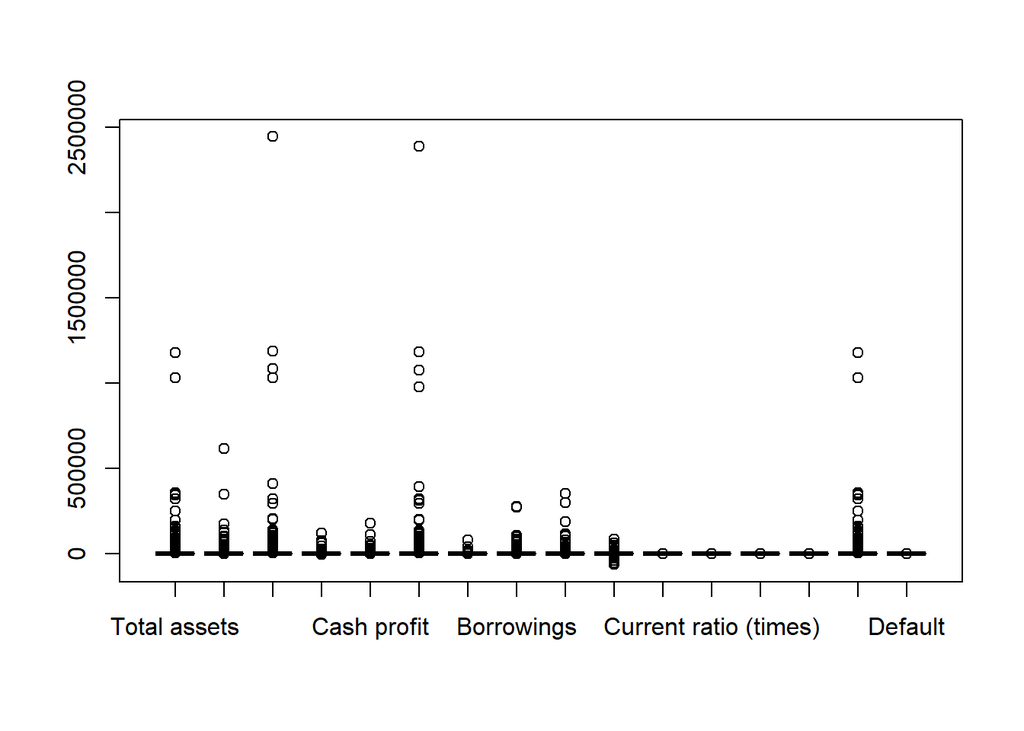

```r
boxplot(Tr_D1)
```

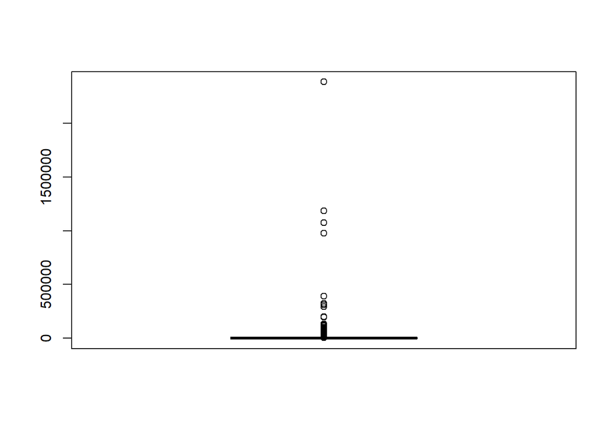

```r
boxplot(Tr_D1$Sales)
boxplot(Tr_D1$Sales)
```

```r
Tr_D2=Tr_D1[which(Tr_D1$`Total assets`<50000),]
summary(Tr_D2)
```

```
##   Total assets       Net worth        Total income      Profit after tax
##  Min.   :    0.1   Min.   :    0.0   Min.   :     0.0   Min.   :-3908.30
##  1st Qu.:   90.0   1st Qu.:   31.1   1st Qu.:   104.5   1st Qu.:    0.50
##  Median :  305.0   Median :  100.7   Median :   430.1   Median :    8.50
##  Mean   : 1541.5   Mean   :  567.1   Mean   :  1824.4   Mean   :   97.55
##  3rd Qu.: 1043.4   3rd Qu.:  365.1   3rd Qu.:  1385.8   3rd Qu.:   49.17
##  Max.   :48113.8   Max.   :28495.1   Max.   :119658.2   Max.   : 9065.10
##                                      NA's   :197        NA's   :131
##   Cash profit           Sales          Total capital      Borrowings
##  Min.   :-2245.70   Min.   :     0.1   Min.   :   0.1   Min.   :    0.1
##  1st Qu.:    2.80   1st Qu.:   110.5   1st Qu.:  12.9   1st Qu.:   23.5
##  Median :   18.35   Median :   442.4   Median :  41.3   Median :   97.1
##  Mean   :  148.79   Mean   :  1809.9   Mean   : 141.3   Mean   :  543.4
##  3rd Qu.:   87.97   3rd Qu.:  1381.9   3rd Qu.:  99.9   3rd Qu.:  336.9
##  Max.   :13129.20   Max.   :117317.5   Max.   :8000.0   Max.   :33367.6
##  NA's   :131        NA's   :258        NA's   :4        NA's   :366
##  Current liabilities & provisions Net working capital Quick ratio (times)
##  Min.   :    0.1                  Min.   :-12564.00   Min.   :  0.000
##  1st Qu.:   17.4                  1st Qu.:    -1.10   1st Qu.:  0.410
##  Median :   67.5                  Median :    16.00   Median :  0.670
##  Mean   :  398.3                  Mean   :    95.09   Mean   :  1.407
##  3rd Qu.:  246.8                  3rd Qu.:    80.60   3rd Qu.:  1.030
##  Max.   :21309.2                  Max.   : 16213.60   Max.   :341.000
##  NA's   :96                       NA's   :32          NA's   :93
##  Current ratio (times) Debt to equity ratio (times)
##  Min.   :  0.000       Min.   :  0.000
##  1st Qu.:  0.930       1st Qu.:  0.220
##  Median :  1.230       Median :  0.790
##  Mean   :  2.139       Mean   :  2.794
##  3rd Qu.:  1.720       3rd Qu.:  1.750
##  Max.   :505.000       Max.   :456.000
##  NA's   :93
##  Cash to current liabilities (times) Total liabilities Default
##  Min.   :  0.0000                    Min.   :    0.1   0:3263
##  1st Qu.:  0.0200                    1st Qu.:   90.0   1: 242
##  Median :  0.0700                    Median :  305.0
##  Mean   :  0.4904                    Mean   : 1541.5
##  3rd Qu.:  0.1900                    3rd Qu.: 1043.4
##  Max.   :165.0000                    Max.   :48113.8
##  NA's   :93
```

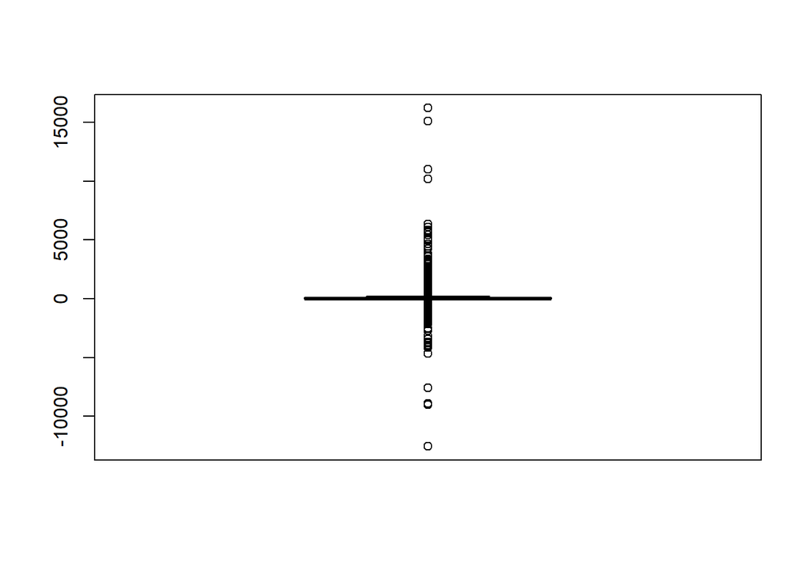

```r
boxplot(Tr_D2$`Net working capital`)
```

```r
dim(Tr_D2)
```

```
## [1] 3505   16
```

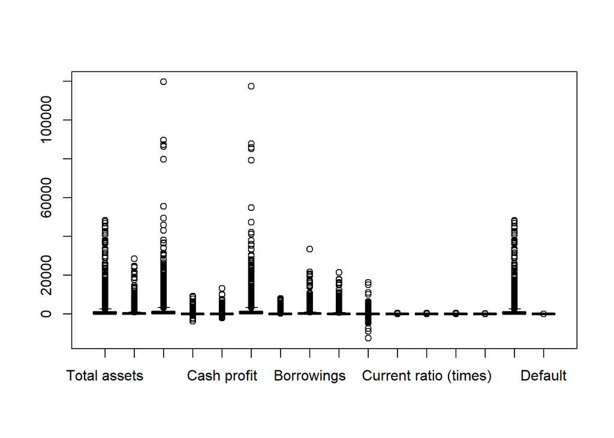

```r
boxplot(Tr_D2)
```

```r
Tr_D3=Tr_D2[which(Tr_D2$`Total income`<50000),]
summary(Tr_D3)
```

```
##   Total assets       Net worth         Total income     Profit after tax
##  Min.   :    0.3   Min.   :    0.10   Min.   :    0.0   Min.   :-3908.30
##  1st Qu.:  108.5   1st Qu.:   36.02   1st Qu.:  104.2   1st Qu.:    0.70
##  Median :  336.1   Median :  108.80   Median :  428.9   Median :    9.10
##  Mean   : 1545.0   Mean   :  564.94   Mean   : 1670.9   Mean   :   91.19
##  3rd Qu.: 1118.4   3rd Qu.:  381.68   3rd Qu.: 1378.3   3rd Qu.:   51.00
##  Max.   :48113.8   Max.   :28495.10   Max.   :49280.5   Max.   : 9065.10
##
##   Cash profit           Sales         Total capital      Borrowings
##  Min.   :-2245.70   Min.   :    0.1   Min.   :   0.1   Min.   :    0.1
##  1st Qu.:    3.20   1st Qu.:  110.2   1st Qu.:  14.9   1st Qu.:   26.5
##  Median :   19.60   Median :  441.1   Median :  43.0   Median :  101.6
##  Mean   :  140.85   Mean   : 1655.8   Mean   : 140.2   Mean   :  540.1
##  3rd Qu.:   90.95   3rd Qu.: 1375.4   3rd Qu.: 100.5   3rd Qu.:  347.8
##  Max.   :13129.20   Max.   :47311.7   Max.   :8000.0   Max.   :33367.6
##                     NA's   :61        NA's   :3        NA's   :281
##  Current liabilities & provisions Net working capital Quick ratio (times)
##  Min.   :    0.1                  Min.   :-12564.00   Min.   :  0.000
##  1st Qu.:   19.9                  1st Qu.:    -0.90   1st Qu.:  0.430
##  Median :   72.1                  Median :    18.90   Median :  0.680
##  Mean   :  387.1                  Mean   :   103.37   Mean   :  1.383
##  3rd Qu.:  258.2                  3rd Qu.:    88.15   3rd Qu.:  1.040
##  Max.   :21309.2                  Max.   : 16213.60   Max.   :341.000
##  NA's   :23                       NA's   :6           NA's   :23
##  Current ratio (times) Debt to equity ratio (times)
##  Min.   :  0.000       Min.   :  0.00
##  1st Qu.:  0.950       1st Qu.:  0.26
##  Median :  1.240       Median :  0.82
##  Mean   :  2.113       Mean   :  2.39
##  3rd Qu.:  1.720       3rd Qu.:  1.78
##  Max.   :505.000       Max.   :341.18
##  NA's   :23
##  Cash to current liabilities (times) Total liabilities Default
##  Min.   :  0.0000                    Min.   :    0.3   0:3104
##  1st Qu.:  0.0300                    1st Qu.:  108.5   1: 198
##  Median :  0.0700                    Median :  336.1
##  Mean   :  0.4824                    Mean   : 1545.0
##  3rd Qu.:  0.1900                    3rd Qu.: 1118.4
##  Max.   :165.0000                    Max.   :48113.8
##  NA's   :23
```

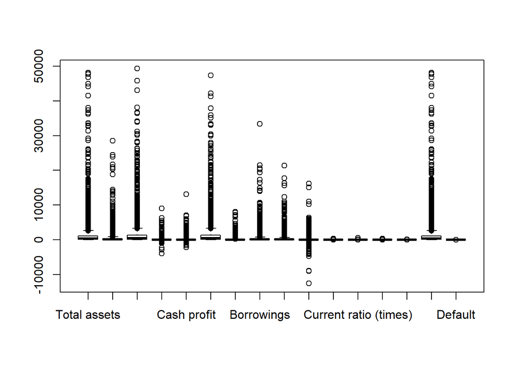

```r
boxplot(Tr_D3)
```

```r
dim(Tr_D3)
```

```
## [1] 3302   16
```

```r
tail(Tr_D3[order(Tr_D3$`Total income`),])
```

```
## # A tibble: 6 x 16
##   `Total assets` `Net worth` `Total income` `Profit after t~ `Cash profit`
##            <dbl>       <dbl>          <dbl>            <dbl>         <dbl>
## 1         32655.      13652.         36476             2669.         3477.
## 2         32927.      14473          36623.            1487.         2365.
## 3         25736.       9756.         38080.            1134.         2120
## 4         48114.      23891.         43105             4442.         5483.
## 5         33521.      20420.         45816.            5480.         7033.
## 6         46799.      18824          49280.            9065.        13129.
## # ... with 11 more variables: Sales <dbl>, `Total capital` <dbl>,
## #   Borrowings <dbl>, `Current liabilities & provisions` <dbl>, `Net
## #   working capital` <dbl>, `Quick ratio (times)` <dbl>, `Current ratio
## #   (times)` <dbl>, `Debt to equity ratio (times)` <dbl>, `Cash to current
## #   liabilities (times)` <dbl>, `Total liabilities` <dbl>, Default <fct>
```

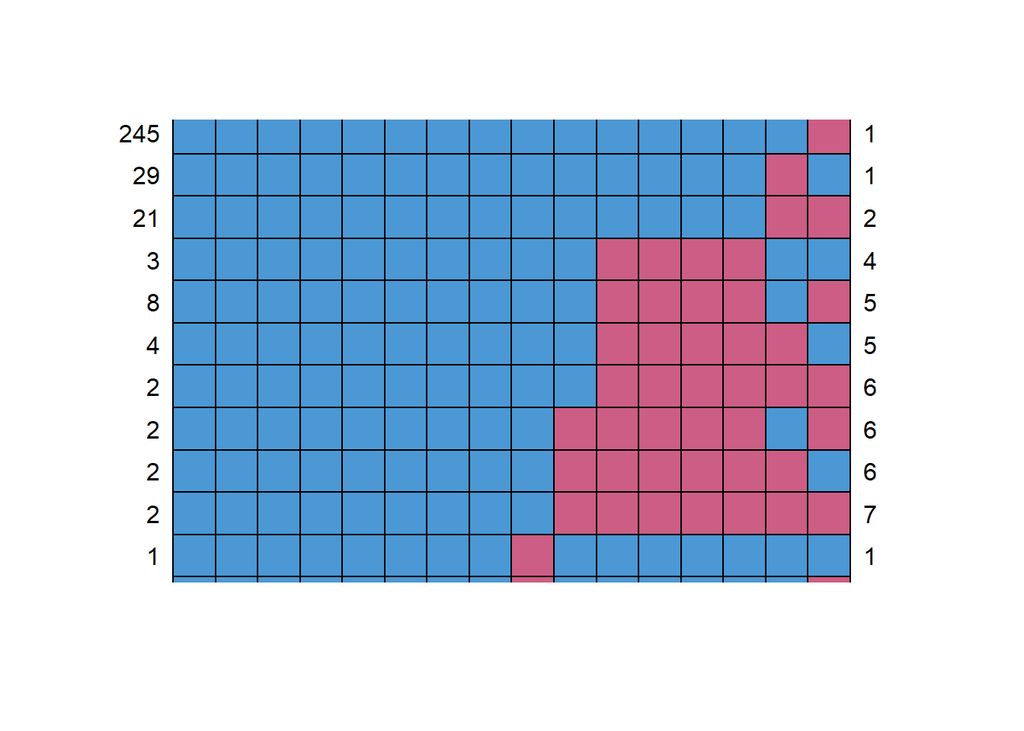

```
##      Total assets Net worth Total income Profit after tax Cash profit
## 2981            1         1            1                1           1
## 245             1         1            1                1           1
## 29              1         1            1                1           1
## 21              1         1            1                1           1
## 3               1         1            1                1           1
## 8               1         1            1                1           1
## 4               1         1            1                1           1
## 2               1         1            1                1           1
## 2               1         1            1                1           1
## 2               1         1            1                1           1
## 2               1         1            1                1           1
## 1               1         1            1                1           1
## 1               1         1            1                1           1
## 1               1         1            1                1           1
```

[output cut: 65 more lines]

```r
## Missing value treatment

md.pattern(Tr_D3)
```

```r
colSums(is.na(Tr_D3))
```

```
##                        Total assets                           Net worth
##                                   0                                   0
##                        Total income                    Profit after tax
##                                   0                                   0
##                         Cash profit                               Sales
##                                   0                                  61
##                       Total capital                          Borrowings
##                                   3                                 281
##    Current liabilities & provisions                 Net working capital
##                                  23                                   6
##                 Quick ratio (times)               Current ratio (times)
##                                  23                                  23
##        Debt to equity ratio (times) Cash to current liabilities (times)
##                                   0                                  23
##                   Total liabilities                             Default
##                                   0                                   0
```

```r
# As we see there are lot of missing values we will use KNN imputation. It will impute the values based on its nearest neighbors. We can also use the Mice function but i am not using that here considering that given column names have spaces inbetween then and the code will throw a parsing error, so we have to change column names before using mice package. We will go with KNN as it is equally reliable for the current dataset


Tr_D4=Tr_D3[,-16]
Tr_D4=data.frame(Tr_D4)

Tr_D5=knnImputation(Tr_D4, k = 5)

colSums(is.na(Tr_D5))
```

```
##                        Total.assets                           Net.worth
##                                   0                                   0
##                        Total.income                    Profit.after.tax
##                                   0                                   0
##                         Cash.profit                               Sales
##                                   0                                   0
##                       Total.capital                          Borrowings
##                                   0                                   0
##    Current.liabilities...provisions                 Net.working.capital
##                                   0                                   0
##                 Quick.ratio..times.               Current.ratio..times.
##                                   0                                   0
##        Debt.to.equity.ratio..times. Cash.to.current.liabilities..times.
##                                   0                                   0
##                   Total.liabilities
##                                   0
```

```r
summary(Tr_D5)
```

```
##   Total.assets       Net.worth         Total.income     Profit.after.tax
##  Min.   :    0.3   Min.   :    0.10   Min.   :    0.0   Min.   :-3908.30
##  1st Qu.:  108.5   1st Qu.:   36.02   1st Qu.:  104.2   1st Qu.:    0.70
##  Median :  336.1   Median :  108.80   Median :  428.9   Median :    9.10
##  Mean   : 1545.0   Mean   :  564.94   Mean   : 1670.9   Mean   :   91.19
##  3rd Qu.: 1118.4   3rd Qu.:  381.68   3rd Qu.: 1378.3   3rd Qu.:   51.00
##  Max.   :48113.8   Max.   :28495.10   Max.   :49280.5   Max.   : 9065.10
##   Cash.profit           Sales         Total.capital       Borrowings
##  Min.   :-2245.70   Min.   :    0.1   Min.   :   0.10   Min.   :    0.10
##  1st Qu.:    3.20   1st Qu.:  102.0   1st Qu.:  14.90   1st Qu.:   21.16
##  Median :   19.60   Median :  421.7   Median :  43.05   Median :   91.35
##  Mean   :  140.85   Mean   : 1626.8   Mean   : 140.16   Mean   :  514.19
##  3rd Qu.:   90.95   3rd Qu.: 1356.7   3rd Qu.: 100.47   3rd Qu.:  317.73
##  Max.   :13129.20   Max.   :47311.7   Max.   :8000.00   Max.   :33367.60
##  Current.liabilities...provisions Net.working.capital  Quick.ratio..times.
##  Min.   :    0.10                 Min.   :-12564.000   Min.   :  0.000
##  1st Qu.:   19.30                 1st Qu.:    -0.875   1st Qu.:  0.430
##  Median :   70.85                 Median :    18.800   Median :  0.680
##  Mean   :  384.51                 Mean   :   103.190   Mean   :  1.385
##  3rd Qu.:  254.60                 3rd Qu.:    87.675   3rd Qu.:  1.050
##  Max.   :21309.20                 Max.   : 16213.600   Max.   :341.000
##  Current.ratio..times. Debt.to.equity.ratio..times.
##  Min.   :  0.000       Min.   :  0.00
##  1st Qu.:  0.950       1st Qu.:  0.26
##  Median :  1.240       Median :  0.82
##  Mean   :  2.114       Mean   :  2.39
##  3rd Qu.:  1.730       3rd Qu.:  1.78
##  Max.   :505.000       Max.   :341.18
##  Cash.to.current.liabilities..times. Total.liabilities
##  Min.   :  0.0000                    Min.   :    0.3
##  1st Qu.:  0.0300                    1st Qu.:  108.5
##  Median :  0.0700                    Median :  336.1
##  Mean   :  0.4833                    Mean   : 1545.0
##  3rd Qu.:  0.1900                    3rd Qu.: 1118.4
##  Max.   :165.0000                    Max.   :48113.8
```

```r
Train_Data=Tr_D5


colnames(Train_Data)
```

```
##  [1] "Total.assets"
##  [2] "Net.worth"
##  [3] "Total.income"
##  [4] "Profit.after.tax"
##  [5] "Cash.profit"
##  [6] "Sales"
##  [7] "Total.capital"
##  [8] "Borrowings"
##  [9] "Current.liabilities...provisions"
## [10] "Net.working.capital"
## [11] "Quick.ratio..times."
## [12] "Current.ratio..times."
## [13] "Debt.to.equity.ratio..times."
## [14] "Cash.to.current.liabilities..times."
## [15] "Total.liabilities"
```

```r
## Creation of new variables

## Profitability

# 1 . Return on Asset

Train_Data$ReturnonAsset=Train_Data$Total.income/Train_Data$Total.assets



# 2. Return on Equity

Train_Data$ReturnonEquity=Train_Data$Profit.after.tax/Train_Data$Net.worth



## Leverage

# 1. Debt to Equity ratio - This ratio already given as part of dataset

# 2. Debt to Capital ratio

Train_Data$DebttoCapital=Train_Data$Borrowings/Train_Data$Total.capital


## Liquidity Ratio

# 1. Current Ratio - given as part of dataset
# 2. Quick Ratio - given as part of dataset
# 3. Cash ratio - given as part of dataset


## Company Size Ratio

# 1. Income to Sales Ratio

Train_Data$Incometosales=Train_Data$Total.income/Train_Data$Sales

# 2. Profit to Sales Ratio

Train_Data$ProfittoSales=Train_Data$Profit.after.tax/Train_Data$Sales

# 3. Profit to Income Ratio

Train_Data$ProfittoIncome=Train_Data$Profit.after.tax/Train_Data$Total.income

Train_Data$ProfittoIncome[is.na(Train_Data$ProfittoIncome)]=median(Train_Data$ProfittoIncome,na.rm = T)



Train_Data=cbind(Train_Data,Tr_D3[,16])

dim(Train_Data)
```

```
## [1] 3302   22
```

## Univariate and Bivariate analysis

For Train and Test Data

```r
## EDA for Train Data

# Observations

# 1. Defaulting companies loses profit by 6 unit per 100 units and non defaulting companies earn profit by 3 units per 100 units of income.


summary(Tr_D$`PAT as % of total income`[Tr_D$Default==0])
```

```
##      Min.   1st Qu.    Median      Mean   3rd Qu.      Max.      NA's
## -9700.000     0.622     2.660    -5.327     6.670   150.000        52
```

```r
summary(Tr_D$`PAT as % of total income`[Tr_D$Default==1])
```

```
##      Min.   1st Qu.    Median      Mean   3rd Qu.      Max.      NA's
## -21340.00    -32.48     -5.95   -217.58      0.00     92.38        16
```

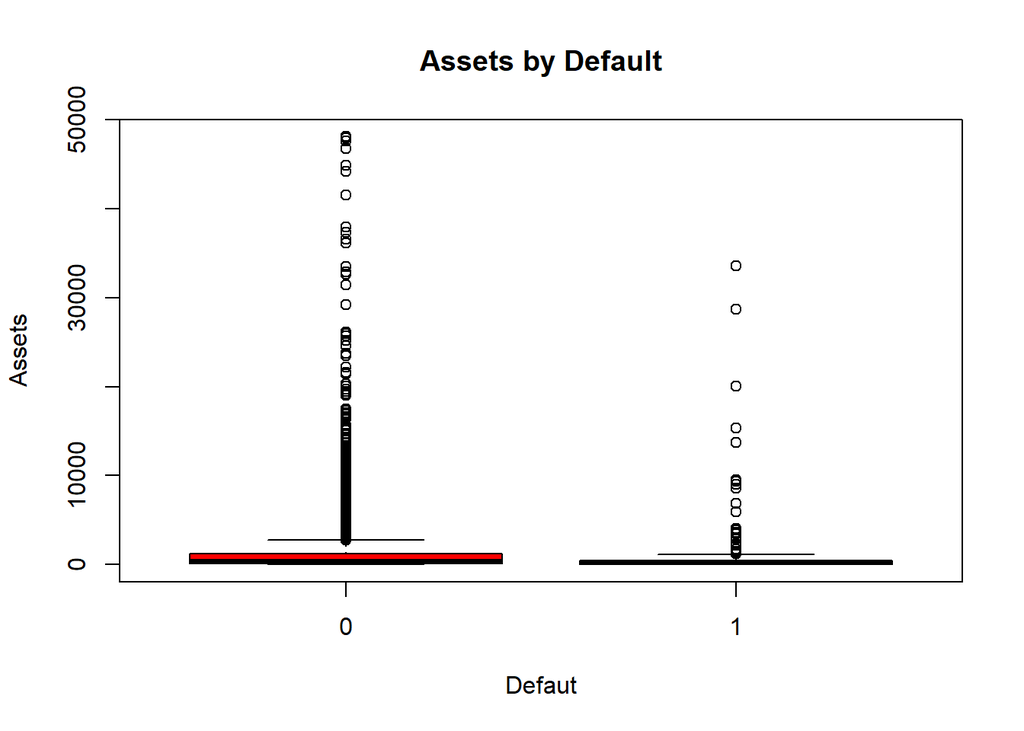

```r
boxplot(Tr_D3$`Total assets`~Tr_D3$Default, xlab="Defaut",
        ylab="Assets",main="Assets by Default",col=c("Red","Green"))
```

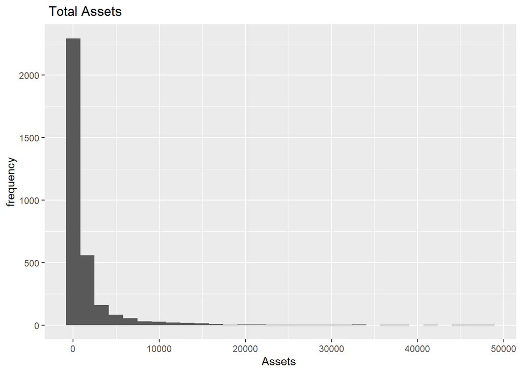

```r
# Numerical

qplot(Train_Data$Total.assets, data = Train_Data, main=" Total Assets ", xlab = "Assets ", ylab = "frequency")
```

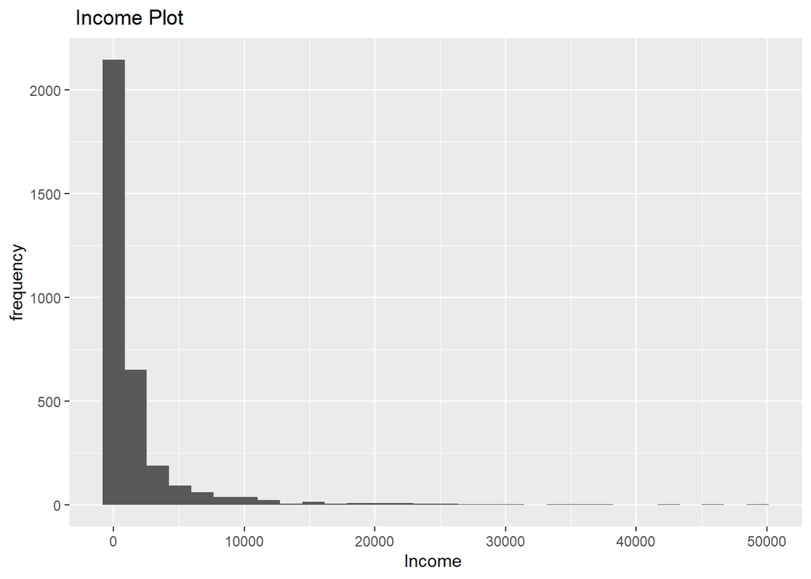

```r
qplot(Train_Data$Total.income, data = Train_Data, main=" Income Plot ", xlab = "Income ", ylab = "frequency")
```

[figure not shown]

```r
qplot(Train_Data$Total.liabilities, data = Train_Data, main=" Liabilities Plot ", xlab = "Income ", ylab = "frequency")
```

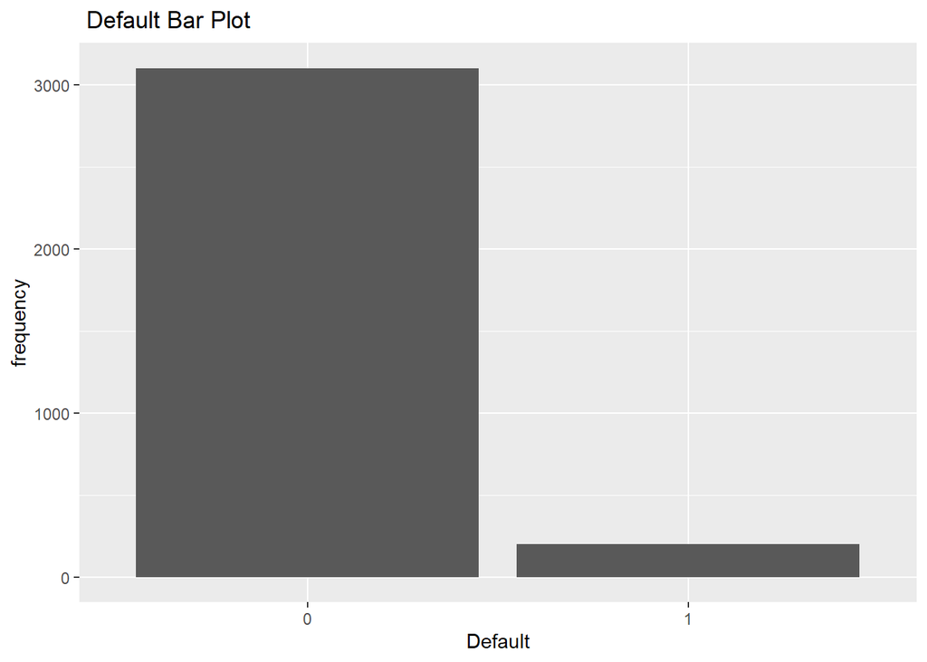

```r
# Categorical

qplot(Train_Data$Default, data = Train_Data, main=" Default Bar Plot", xlab = "Default", ylab = "frequency")
```

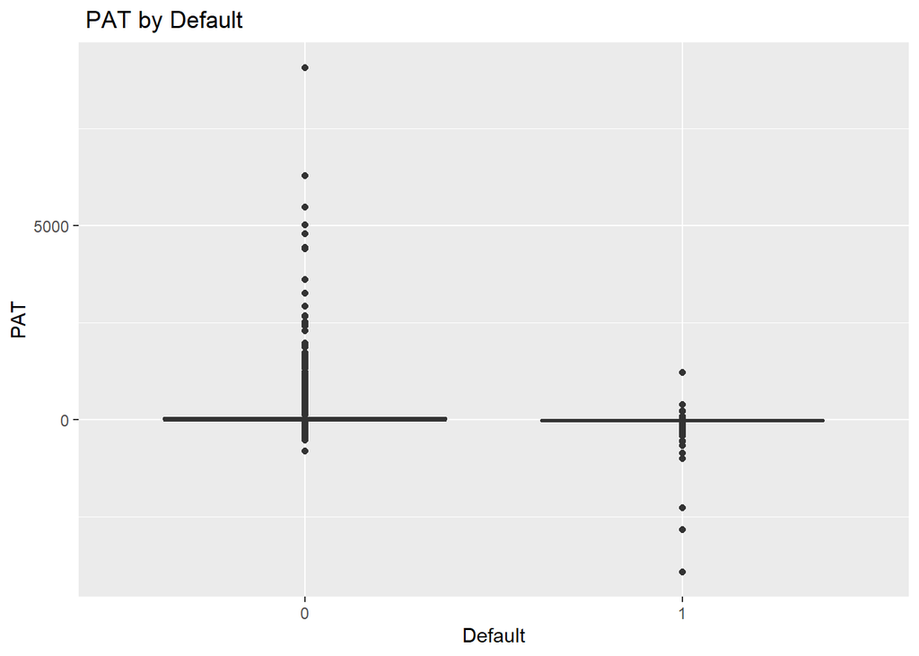

```r
# Categorical and numerical together

qplot(Train_Data$Default,Train_Data$Profit.after.tax, data = Train_Data, , geom="boxplot",main=" PAT by Default", xlab = "Default", ylab ="PAT")
```

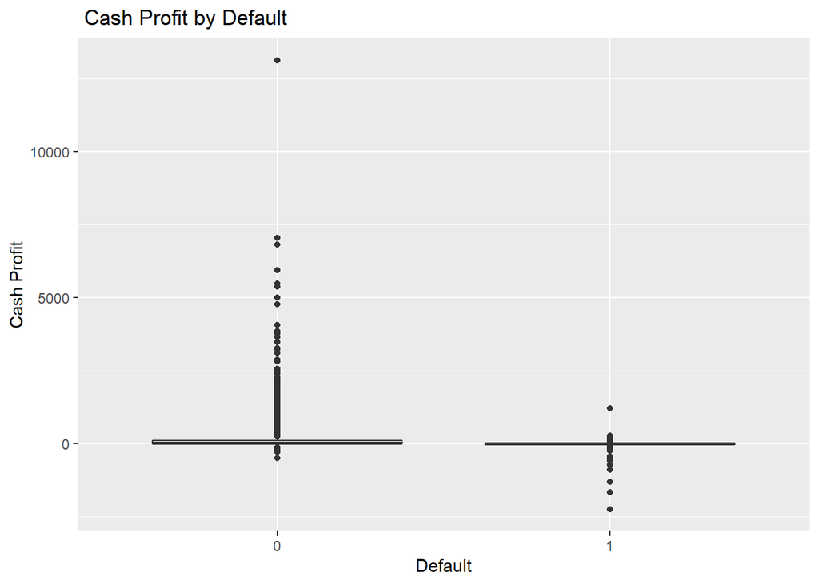

```r
qplot(Train_Data$Default,Train_Data$Cash.profit, data = Train_Data, , geom="boxplot",main=" Cash Profit by Default", xlab = "Default", ylab ="Cash Profit")
```

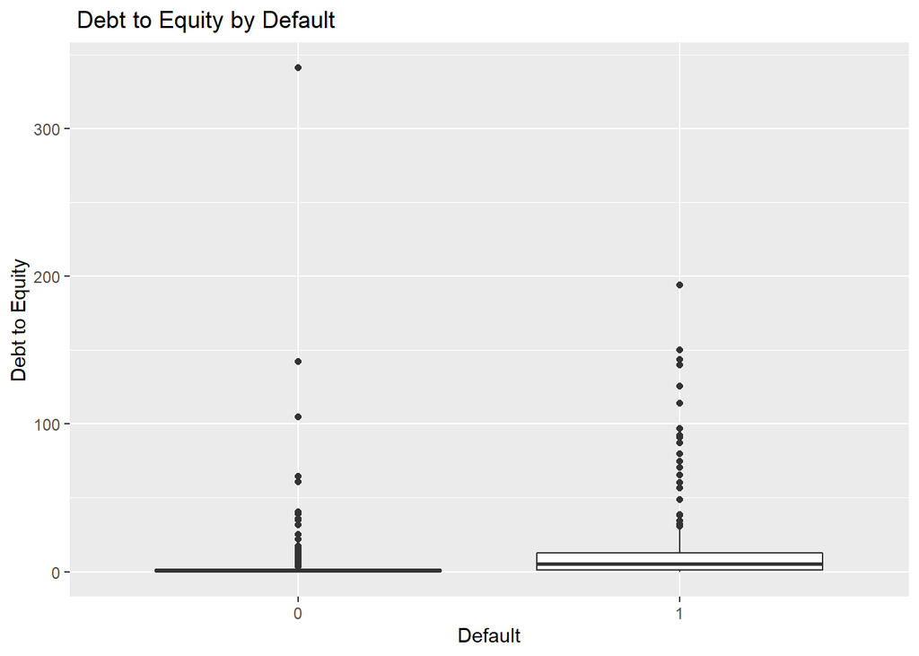

```r
qplot(Train_Data$Default,Train_Data$Debt.to.equity.ratio..times., data = Train_Data, , geom="boxplot",main=" Debt to Equity by Default", xlab = "Default", ylab ="Debt to Equity")
```

[figure not shown]

```r
qplot(Train_Data$Default,Train_Data$ReturnonAsset, data = Train_Data, , geom="boxplot",main=" Return on Equity by Default", xlab = "Default", ylab ="Return on Equity")
```

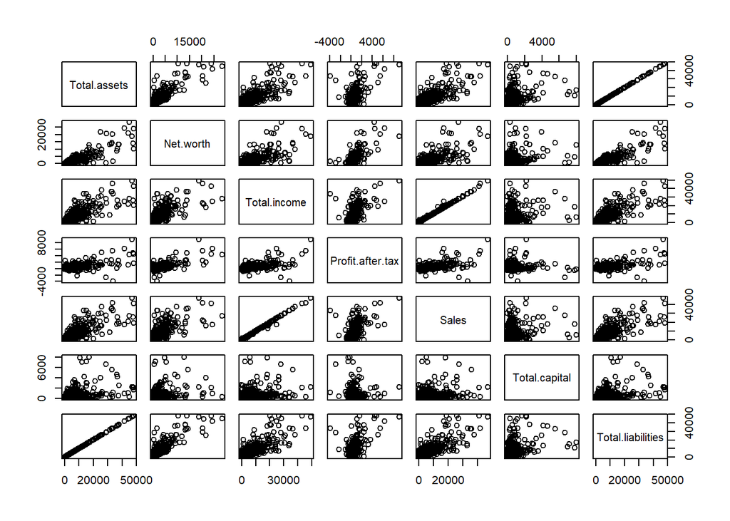

```r
# Numerical against numerical and color the dots by categorical variable

plot(Train_Data[,c(1:4,6,7,15)])
```

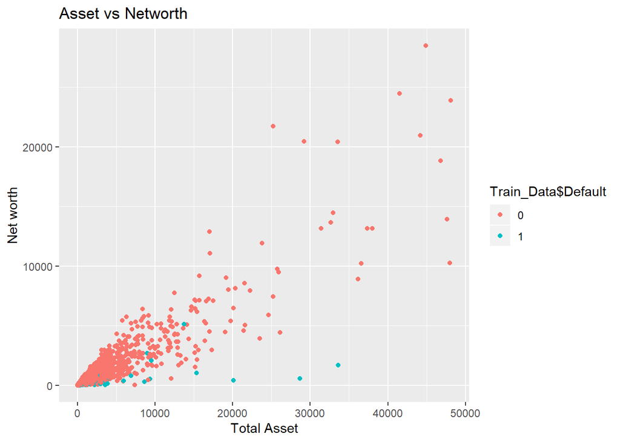

```r
qplot(Train_Data$Total.assets, Train_Data$Net.worth, data = Train_Data, color=Train_Data$Default , main = "Asset vs Networth", xlab = "Total Asset", ylab = "Net worth")
```

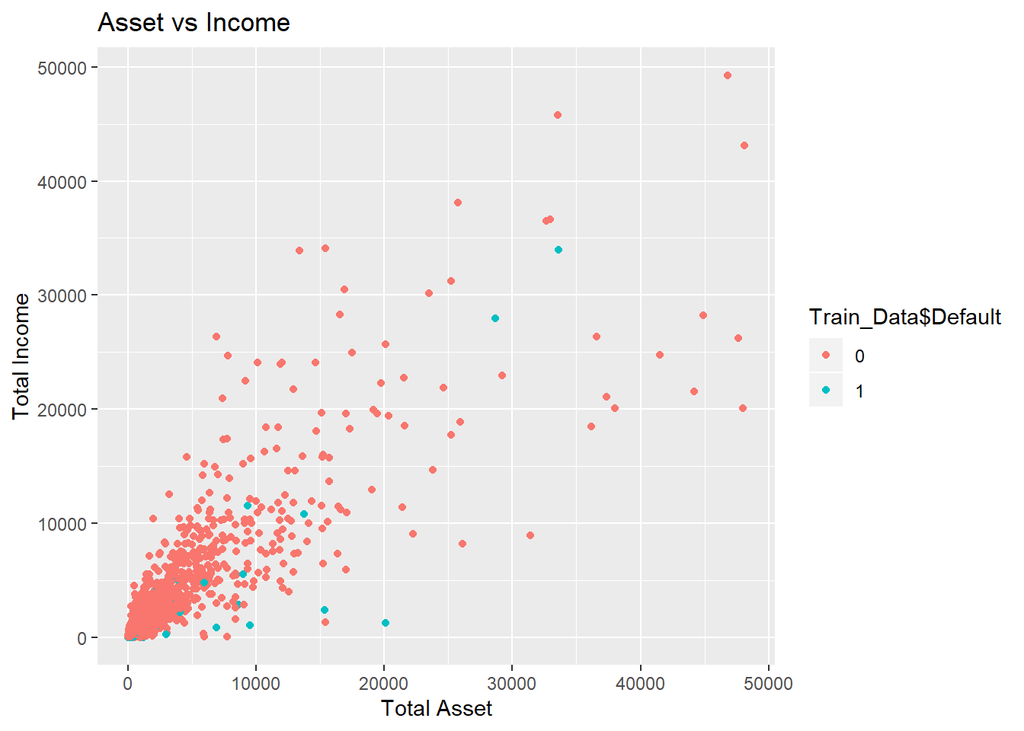

```r
qplot(Train_Data$Total.assets, Train_Data$Total.income, data = Train_Data, color=Train_Data$Default , main = "Asset vs Income", xlab = "Total Asset", ylab = "Total Income")
```

[figure not shown]

```r
qplot(Train_Data$Sales, Train_Data$Profit.after.tax, data = Train_Data, color=Train_Data$Default , main = "Asset vs Income", xlab = "Sales", ylab = "Profit After Tax")
```

[figure not shown]

```r
qplot(Train_Data$Total.liabilities, Train_Data$Profit.after.tax, data = Train_Data, color=Train_Data$Default , main = "Liabilities vs PAT", xlab = "PAT", ylab = "Total Liabilities")
```

```r
by(Train_Data, INDICES = Train_Data$Default, FUN = summary)
```

```
## Train_Data$Default: 0
##   Total.assets       Net.worth        Total.income     Profit.after.tax
##  Min.   :    0.3   Min.   :    0.2   Min.   :    0.0   Min.   :-799.90
##  1st Qu.:  117.2   1st Qu.:   41.7   1st Qu.:  119.2   1st Qu.:   1.20
##  Median :  349.7   Median :  119.2   Median :  466.2   Median :  10.90
##  Mean   : 1566.9   Mean   :  592.5   Mean   : 1723.3   Mean   : 102.16
##  3rd Qu.: 1177.4   3rd Qu.:  408.6   3rd Qu.: 1441.1   3rd Qu.:  54.42
##  Max.   :48113.8   Max.   :28495.1   Max.   :49280.5   Max.   :9065.10
##   Cash.profit            Sales         Total.capital      Borrowings
##  Min.   : -509.700   Min.   :    0.1   Min.   :   0.1   Min.   :    0.1
##  1st Qu.:    4.675   1st Qu.:  115.0   1st Qu.:  15.0   1st Qu.:   21.2
##  Median :   23.000   Median :  455.0   Median :  42.9   Median :   92.6
##  Mean   :  152.985   Mean   : 1678.0   Mean   : 135.3   Mean   :  509.3
##  3rd Qu.:   98.350   3rd Qu.: 1412.2   3rd Qu.: 100.2   3rd Qu.:  323.9
##  Max.   :13129.200   Max.   :47311.7   Max.   :8000.0   Max.   :33367.6
##  Current.liabilities...provisions Net.working.capital Quick.ratio..times.
##  Min.   :    0.10                 Min.   :-12564.00   Min.   :  0.000
##  1st Qu.:   20.47                 1st Qu.:     0.20   1st Qu.:  0.450
##  Median :   73.85                 Median :    22.05   Median :  0.690
##  Mean   :  385.59                 Mean   :   115.37   Mean   :  1.383
##  3rd Qu.:  263.15                 3rd Qu.:    95.75   3rd Qu.:  1.060
##  Max.   :21309.20                 Max.   : 16213.60   Max.   :341.000
##  Current.ratio..times. Debt.to.equity.ratio..times.
##  Min.   :  0.000       Min.   :  0.000
##  1st Qu.:  0.990       1st Qu.:  0.240
##  Median :  1.260       Median :  0.780
##  Mean   :  2.131       Mean   :  1.565
##  3rd Qu.:  1.750       3rd Qu.:  1.620
##  Max.   :505.000       Max.   :341.180
##  Cash.to.current.liabilities..times. Total.liabilities ReturnonAsset
##  Min.   :  0.0000                    Min.   :    0.3   Min.   : 0.0000
##  1st Qu.:  0.0300                    1st Qu.:  117.2   1st Qu.: 0.7414
##  Median :  0.0700                    Median :  349.7   Median : 1.1343
##  Mean   :  0.4587                    Mean   : 1566.9   Mean   : 1.3577
##  3rd Qu.:  0.2000                    3rd Qu.: 1177.4   3rd Qu.: 1.6878
##  Max.   :165.0000                    Max.   :48113.8   Max.   :39.4545
##  ReturnonEquity      DebttoCapital      Incometosales
##  Min.   :-13.85714   Min.   :  0.0008   Min.   :  0.000
##  1st Qu.:  0.02884   1st Qu.:  0.8072   1st Qu.:  1.002
##  Median :  0.10369   Median :  2.5120   Median :  1.008
```

[output cut: 53 more lines]

```
##  Max.   :33592.2   Max.   :5.314776   Max.   :160.46154
##  DebttoCapital       Incometosales       ProfittoSales
##  Min.   :  0.00062   Min.   :   0.0008   Min.   : -43.5714
##  1st Qu.:  0.80480   1st Qu.:   1.0010   1st Qu.:  -0.3213
##  Median :  1.95849   Median :   1.0120   Median :  -0.0890
##  Mean   :  6.05922   Mean   :  11.4831   Mean   :   6.6261
##  3rd Qu.:  4.40123   3rd Qu.:   1.0501   3rd Qu.:  -0.0088
##  Max.   :109.32143   Max.   :1585.5000   Max.   :1171.5000
##  ProfittoIncome       Default
##  Min.   :-213.40000   0:  0
##  1st Qu.:  -0.37608   1:198
##  Median :  -0.10073
##  Mean   :  -2.49447
##  3rd Qu.:  -0.01343
##  Max.   :   0.92383
```

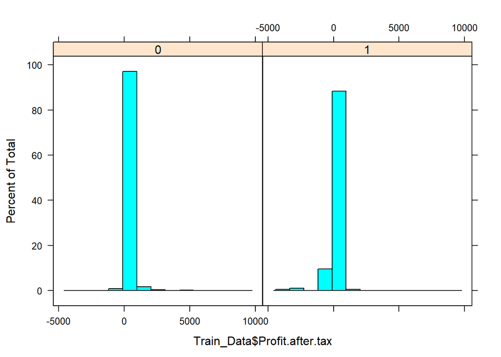

```r
histogram(~Train_Data$Profit.after.tax|factor(Train_Data$Default), data = Train_Data)
```

## Logistic Regression model on important variables

We build the model on the below variables

1. Profit to Income
2. Income to Sales
3. Current Ratio
4. Debt to Equity
5. Debt to Capital
6. Return on Equity
7. Return on Asset

We notice that Probability of default is a logit function with coefficient and intercept. The positive sign in the coefficient indicates that as the value increases , the probability of default increases and negative sign means they are inversly proportional ie as the value increases chance of default decrease..for eg as PAT increase , risk of default decrease

when we check the VIF for multicolinearity we find that all the variables have scores less than 3 so they are are independent. The same is visible from correlation plot.

```r
## Model Building for Train Data

colnames(Train_Data)
```

```
##  [1] "Total.assets"
##  [2] "Net.worth"
##  [3] "Total.income"
##  [4] "Profit.after.tax"
##  [5] "Cash.profit"
##  [6] "Sales"
##  [7] "Total.capital"
##  [8] "Borrowings"
##  [9] "Current.liabilities...provisions"
## [10] "Net.working.capital"
## [11] "Quick.ratio..times."
## [12] "Current.ratio..times."
## [13] "Debt.to.equity.ratio..times."
## [14] "Cash.to.current.liabilities..times."
## [15] "Total.liabilities"
## [16] "ReturnonAsset"
## [17] "ReturnonEquity"
## [18] "DebttoCapital"
## [19] "Incometosales"
## [20] "ProfittoSales"
## [21] "ProfittoIncome"
## [22] "Default"
```

```r
# Building logistic regression model

attach(Train_Data)


Tr_L1=glm(Train_Data$Default~ProfittoIncome, data = Train_Data, family = binomial)
summary(Tr_L1)
```

```
##
## Call:
## glm(formula = Train_Data$Default ~ ProfittoIncome, family = binomial,
##     data = Train_Data)
##
## Deviance Residuals:
##     Min       1Q   Median       3Q      Max
## -4.0558  -0.3442  -0.3437  -0.3428   2.4307
##
## Coefficients:
##                Estimate Std. Error z value Pr(>|z|)
## (Intercept)    -2.79572    0.07485 -37.351  < 2e-16 ***
## ProfittoIncome -0.11361    0.02441  -4.654 3.25e-06 ***
## ---
## Signif. codes:  0 '***' 0.001 '**' 0.01 '*' 0.05 '.' 0.1 ' ' 1
##
## (Dispersion parameter for binomial family taken to be 1)
##
##     Null deviance: 1498.2  on 3301  degrees of freedom
## Residual deviance: 1465.4  on 3300  degrees of freedom
## AIC: 1469.4
##
## Number of Fisher Scoring iterations: 5
```

```r
# using company size measures as predictor

Tr_L2=glm(Train_Data$Default~ProfittoIncome+Incometosales, data = Train_Data, family = binomial)
summary(Tr_L2)
```

```
##
## Call:
## glm(formula = Train_Data$Default ~ ProfittoIncome + Incometosales,
##     family = binomial, data = Train_Data)
##
## Deviance Residuals:
##     Min       1Q   Median       3Q      Max
## -4.0867  -0.3423  -0.3419  -0.3410   2.4259
##
## Coefficients:
##                Estimate Std. Error z value Pr(>|z|)
## (Intercept)    -2.81221    0.07545 -37.273  < 2e-16 ***
## ProfittoIncome -0.11502    0.02452  -4.691 2.72e-06 ***
## Incometosales   0.00557    0.00276   2.018   0.0436 *
## ---
## Signif. codes:  0 '***' 0.001 '**' 0.01 '*' 0.05 '.' 0.1 ' ' 1
##
## (Dispersion parameter for binomial family taken to be 1)
##
##     Null deviance: 1498.2  on 3301  degrees of freedom
## Residual deviance: 1456.6  on 3299  degrees of freedom
## AIC: 1462.6
##
## Number of Fisher Scoring iterations: 5
```

```r
# Using liquidity measures as predictor

Tr_L3=glm(Train_Data$Default~ProfittoIncome+Current.ratio..times.+Incometosales, data = Train_Data, family = binomial)
summary(Tr_L3)
```

```
##
## Call:
## glm(formula = Train_Data$Default ~ ProfittoIncome + Current.ratio..times. +
##     Incometosales, family = binomial, data = Train_Data)
##
## Deviance Residuals:
##     Min       1Q   Median       3Q      Max
## -4.0874  -0.3429  -0.3423  -0.3412   2.6283
##
## Coefficients:
##                        Estimate Std. Error z value Pr(>|z|)
## (Intercept)           -2.802504   0.080315 -34.894  < 2e-16 ***
## ProfittoIncome        -0.115039   0.024508  -4.694 2.68e-06 ***
## Current.ratio..times. -0.004917   0.014645  -0.336   0.7371
## Incometosales          0.005554   0.002759   2.013   0.0441 *
## ---
## Signif. codes:  0 '***' 0.001 '**' 0.01 '*' 0.05 '.' 0.1 ' ' 1
##
## (Dispersion parameter for binomial family taken to be 1)
##
##     Null deviance: 1498.2  on 3301  degrees of freedom
## Residual deviance: 1456.5  on 3298  degrees of freedom
## AIC: 1464.5
##
## Number of Fisher Scoring iterations: 6
```

```r
Tr_L4=glm(Train_Data$Default~ProfittoIncome+Incometosales+Current.ratio..times.+Cash.to.current.liabilities..times., data = Train_Data, family = binomial)
summary(Tr_L4)
```

```
##
## Call:
## glm(formula = Train_Data$Default ~ ProfittoIncome + Incometosales +
##     Current.ratio..times. + Cash.to.current.liabilities..times.,
##     family = binomial, data = Train_Data)
##
## Deviance Residuals:
##     Min       1Q   Median       3Q      Max
## -4.2968  -0.3670  -0.3400  -0.3007   4.9465
##
## Coefficients:
##                                      Estimate Std. Error z value Pr(>|z|)
## (Intercept)                         -2.207914   0.143384 -15.399  < 2e-16
## ProfittoIncome                      -0.121856   0.027485  -4.434 9.27e-06
## Incometosales                        0.004516   0.002633   1.715   0.0863
## Current.ratio..times.               -0.527794   0.117382  -4.496 6.91e-06
## Cash.to.current.liabilities..times.  0.539643   0.117248   4.603 4.17e-06
##
## (Intercept)                         ***
## ProfittoIncome                      ***
## Incometosales                       .
## Current.ratio..times.               ***
## Cash.to.current.liabilities..times. ***
## ---
## Signif. codes:  0 '***' 0.001 '**' 0.01 '*' 0.05 '.' 0.1 ' ' 1
##
## (Dispersion parameter for binomial family taken to be 1)
##
##     Null deviance: 1498.2  on 3301  degrees of freedom
## Residual deviance: 1425.3  on 3297  degrees of freedom
## AIC: 1435.3
##
## Number of Fisher Scoring iterations: 8
```

```r
# Using leverage measures as predictor

Tr_L5=glm(Train_Data$Default~ProfittoIncome+Incometosales+Current.ratio..times.+Debt.to.equity.ratio..times.+DebttoCapital, data = Train_Data, family = binomial)
summary(Tr_L5)
```

```
##
## Call:
## glm(formula = Train_Data$Default ~ ProfittoIncome + Incometosales +
##     Current.ratio..times. + Debt.to.equity.ratio..times. + DebttoCapital,
##     family = binomial, data = Train_Data)
##
## Deviance Residuals:
##     Min       1Q   Median       3Q      Max
## -8.4904  -0.3192  -0.3084  -0.2958   2.9309
##
## Coefficients:
##                               Estimate Std. Error z value Pr(>|z|)
## (Intercept)                  -2.980531   0.090934 -32.777  < 2e-16 ***
## ProfittoIncome               -0.099912   0.024797  -4.029  5.6e-05 ***
## Incometosales                 0.005893   0.002789   2.113  0.03459 *
## Current.ratio..times.        -0.039849   0.016617  -2.398  0.01648 *
## Debt.to.equity.ratio..times.  0.101704   0.012092   8.411  < 2e-16 ***
## DebttoCapital                -0.019182   0.007336  -2.615  0.00893 **
## ---
## Signif. codes:  0 '***' 0.001 '**' 0.01 '*' 0.05 '.' 0.1 ' ' 1
##
## (Dispersion parameter for binomial family taken to be 1)
##
##     Null deviance: 1498.2  on 3301  degrees of freedom
## Residual deviance: 1309.2  on 3296  degrees of freedom
## AIC: 1321.2
##
## Number of Fisher Scoring iterations: 8
```

```r
# checking VIF for multicolinearity and removing the variable

vif(Tr_L5)
```

```
##               ProfittoIncome                Incometosales
##                     1.003387                     1.001128
##        Current.ratio..times. Debt.to.equity.ratio..times.
##                     1.195489                     1.402248
##                DebttoCapital
##                     1.227797
```

```r
# Using profitbility measures as predictor
Tr_L6=glm(Train_Data$Default~ProfittoIncome+Incometosales+Current.ratio..times.+Debt.to.equity.ratio..times.+DebttoCapital+ReturnonEquity, data = Train_Data, family = binomial)
summary(Tr_L6)
```

```
##
## Call:
## glm(formula = Train_Data$Default ~ ProfittoIncome + Incometosales +
##     Current.ratio..times. + Debt.to.equity.ratio..times. + DebttoCapital +
##     ReturnonEquity, family = binomial, data = Train_Data)
##
## Deviance Residuals:
##     Min       1Q   Median       3Q      Max
## -7.5567  -0.3177  -0.3072  -0.2959   4.4896
##
## Coefficients:
##                               Estimate Std. Error z value Pr(>|z|)
## (Intercept)                  -2.988481   0.091180 -32.776  < 2e-16 ***
## ProfittoIncome               -0.094493   0.025096  -3.765 0.000166 ***
## Incometosales                 0.009816   0.005207   1.885 0.059384 .
## Current.ratio..times.        -0.035371   0.016554  -2.137 0.032618 *
## Debt.to.equity.ratio..times.  0.093626   0.012714   7.364 1.79e-13 ***
## DebttoCapital                -0.017082   0.007204  -2.371 0.017727 *
## ReturnonEquity               -0.071168   0.039718  -1.792 0.073157 .
## ---
## Signif. codes:  0 '***' 0.001 '**' 0.01 '*' 0.05 '.' 0.1 ' ' 1
##
## (Dispersion parameter for binomial family taken to be 1)
##
##     Null deviance: 1498.2  on 3301  degrees of freedom
## Residual deviance: 1293.7  on 3295  degrees of freedom
## AIC: 1307.7
##
## Number of Fisher Scoring iterations: 22
```

```r
Tr_L7=glm(Train_Data$Default~ProfittoIncome+Incometosales+Current.ratio..times.+Debt.to.equity.ratio..times.+DebttoCapital+ReturnonEquity+ReturnonAsset, data = Train_Data, family = binomial)
summary(Tr_L7)
```

```
##
## Call:
## glm(formula = Train_Data$Default ~ ProfittoIncome + Incometosales +
##     Current.ratio..times. + Debt.to.equity.ratio..times. + DebttoCapital +
##     ReturnonEquity + ReturnonAsset, family = binomial, data = Train_Data)
##
## Deviance Residuals:
##     Min       1Q   Median       3Q      Max
## -7.2591  -0.3444  -0.2962  -0.2384   4.5381
##
## Coefficients:
##                               Estimate Std. Error z value Pr(>|z|)
## (Intercept)                  -2.265359   0.151902 -14.913  < 2e-16 ***
## ProfittoIncome               -0.065495   0.023558  -2.780  0.00543 **
## Incometosales                 0.012269   0.005013   2.447  0.01439 *
## Current.ratio..times.        -0.039414   0.015975  -2.467  0.01361 *
## Debt.to.equity.ratio..times.  0.087283   0.011978   7.287 3.17e-13 ***
## DebttoCapital                -0.015525   0.006725  -2.308  0.02098 *
## ReturnonEquity               -0.071093   0.033580  -2.117  0.03425 *
## ReturnonAsset                -0.644777   0.126185  -5.110 3.23e-07 ***
## ---
## Signif. codes:  0 '***' 0.001 '**' 0.01 '*' 0.05 '.' 0.1 ' ' 1
##
## (Dispersion parameter for binomial family taken to be 1)
##
##     Null deviance: 1498.2  on 3301  degrees of freedom
## Residual deviance: 1260.7  on 3294  degrees of freedom
## AIC: 1276.7
##
## Number of Fisher Scoring iterations: 9
```

```r
# These coffiencients are meanigful and they are signficantly different from zero and hence are important predictors in identifying default
# Positive values of coefficient tells that higher the value , higher is chance of default i.e more debt means more chances of default. For negative values , higher the value lesser is chance of default i.e more profit means lesser chance of default
# when we check the VIF for multicolinearity we find that all the variables have scores less than 3 so they are are independent.

vif(Tr_L7)
```

```
##               ProfittoIncome                Incometosales
##                     1.059584                     1.020419
##        Current.ratio..times. Debt.to.equity.ratio..times.
##                     1.188565                     1.502964
##                DebttoCapital               ReturnonEquity
##                     1.252656                     1.108094
##                ReturnonAsset
##                     1.068494
```

```r
# Check for Multicolinearity thru corrplot and VIF
colnames(Train_Data)
```

```
##  [1] "Total.assets"
##  [2] "Net.worth"
##  [3] "Total.income"
##  [4] "Profit.after.tax"
##  [5] "Cash.profit"
##  [6] "Sales"
##  [7] "Total.capital"
##  [8] "Borrowings"
##  [9] "Current.liabilities...provisions"
## [10] "Net.working.capital"
## [11] "Quick.ratio..times."
## [12] "Current.ratio..times."
## [13] "Debt.to.equity.ratio..times."
## [14] "Cash.to.current.liabilities..times."
## [15] "Total.liabilities"
## [16] "ReturnonAsset"
## [17] "ReturnonEquity"
## [18] "DebttoCapital"
## [19] "Incometosales"
## [20] "ProfittoSales"
## [21] "ProfittoIncome"
## [22] "Default"
```

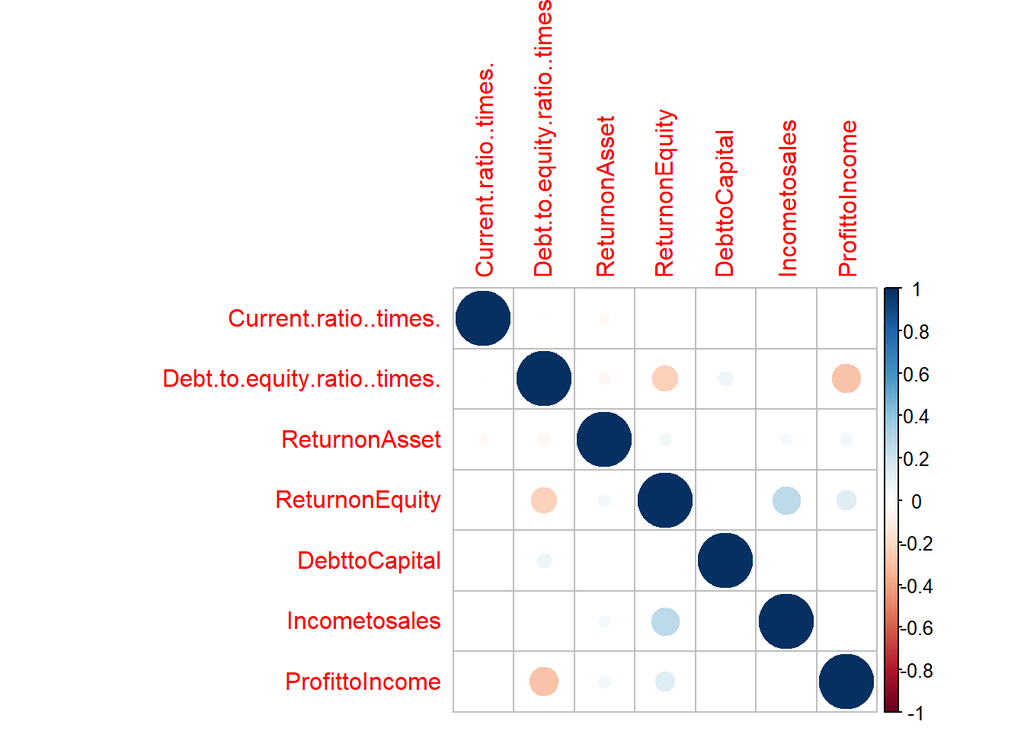

```r
corrplot(cor(Train_Data[,c(12,13,16,17,18,19,21)]))
```

```r
## Prediction for Train Set

plot(Train_Data$Default,Tr_L7$fitted.values)

summary(Tr_L7$fitted.values)
```

```
##    Min. 1st Qu.  Median    Mean 3rd Qu.    Max.
## 0.00000 0.03185 0.04561 0.05996 0.06118 1.00000
```

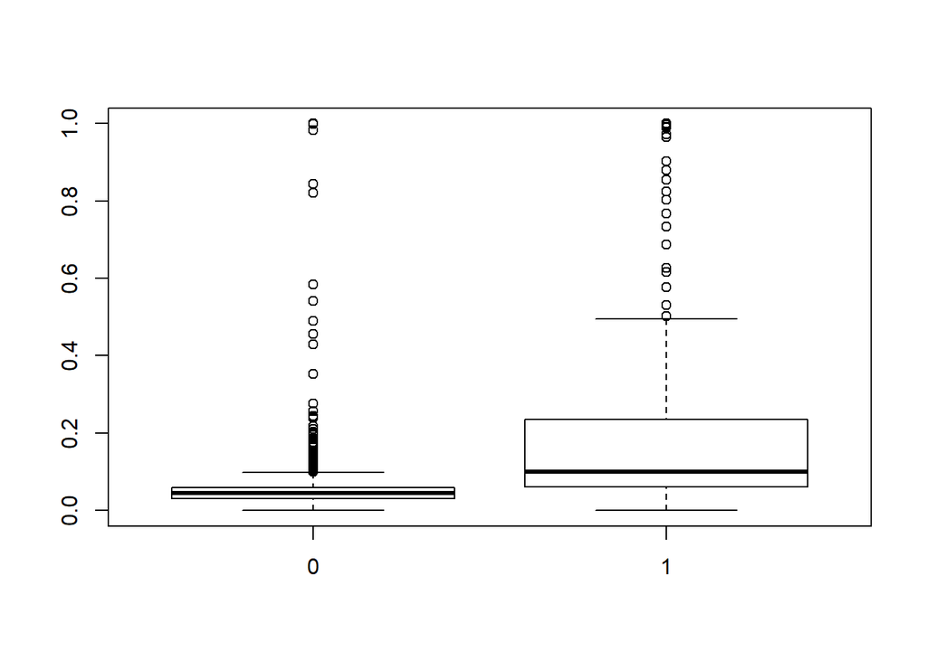

```r
plot(as.factor(Tr_L7$y),Tr_L7$fitted.values)
```

```r
## Doing the prediction using the Train Data

Pred.Train=predict(Tr_L7,newdata = Train_Data,type = "response")

plot(Train_Data$Default,Pred.Train)
```

[output not shown]

## Model performance for Train Set

We take threshold of 8% to find that below this threshold there is minimum prob. of default and above this threshold the risk of default increases.

OVerall Accuracy - 90% ie in identifying the 1s and 0s correctly which means 10% is missclassification

Sensitivity - 63% ie ability of model to predicting 1s correctly. We can increase this value by reducing the threshold but that will also increase the Loss rate and missclasification.

Specificity - 92% , the ability to identify 0s correctly

Loss - 2.5% current loss stands at 2.5% i.e it is the rate for which the model actually said , company will not default but actually company defaulted.

ROC - 82%

KS Calculation -(Difference between %Cumulative Right and % Cumulative Wrong) KS values intrepret that the model is moderatley good in terms of separating the “1”s and “0”s and we can interpret that the model holds a good prediction ability.

KS Score - 58%

AUC calculation -Larger the AUC and larger Gini better the model is ..Gini = 2 AUC-1),AUC is the % of Box that is under the ROC curve

AUC - 82%

Concordance - 82%

```r
## Model Performance for Train Set

Train.logit=confusion.matrix(Train_Data$Default,Pred.Train,threshold = 0.08)
Train.logit
```

```
##     obs
## pred    0   1
##    0 2854  73
##    1  250 125
## attr(,"class")
## [1] "confusion.matrix"
```

```r
## Accuracy of model

accuracy.LR<-sum(diag(Train.logit))/sum(Train.logit)
accuracy.LR
```

```
## [1] 0.9021805
```

```r
## Sensitivity

sensitivity.LR<-Train.logit[2,2]/(Train.logit[1,2]+Train.logit[2,2])
sensitivity.LR
```

```
## [1] 0.6313131
```

```r
## Specificity

specificity.LR<-Train.logit[1,1]/(Train.logit[1,1]+Train.logit[2,1])
specificity.LR
```

```
## [1] 0.9194588
```

```r
## Loss Function - When we predicted company will not default but actually company defaulted
loss.LR<-Train.logit[1,2]/(Train.logit[1,2]+Train.logit[1,1])
loss.LR
```

```
## [1] 0.02494021
```

```r
## OTher Model performance for Train Data set

## Roc curve for the model
library(ROCR)
ROCRTrain = prediction(Pred.Train,Train_Data$Default)
as.numeric(performance(ROCRTrain, "auc")@y.values)
```

```
## [1] 0.819516
```

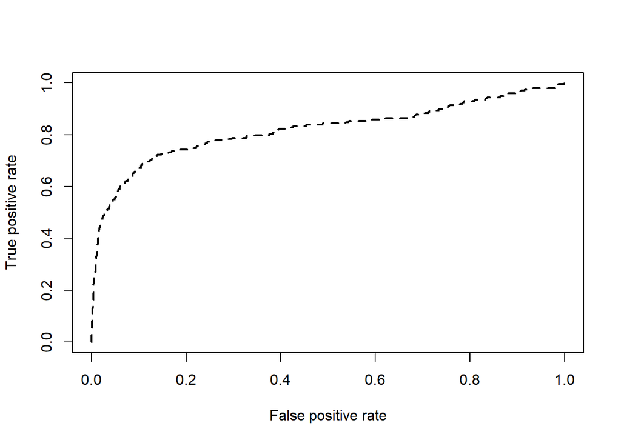

```r
perf = performance(ROCRTrain, "tpr","fpr")
plot(perf,col="black",lty=2, lwd=2)
```

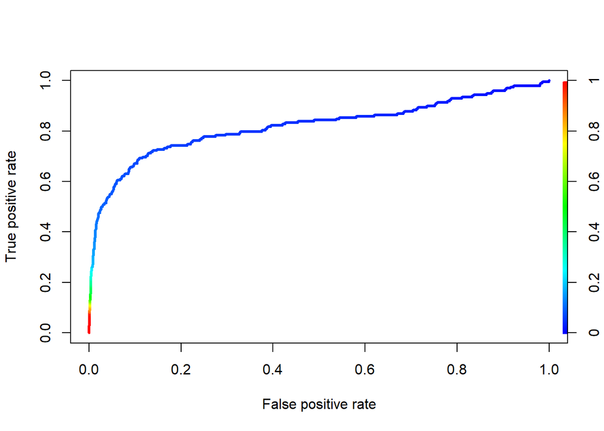

```r
plot(perf,lwd=3,colorize = TRUE)
```

```r
## KS Calculation -(Difference between %Cumulative Right and % Cumulative Wrong)
## KS values intrepret that the model is moderatley good in terms of separating the "1"s and "0"s and we can interpret that the model holds a good prediction ability.

KS_Train=max(perf@y.values[[1]]-perf@x.values[[1]])
print(KS_Train)
```

```
## [1] 0.5842217
```

```r
## AUC calculation -Larger the AUC and larger Gini better the model is ..Gini = 2 AUC-1),AUC is the % of Box that is under the ROC curve

AUC_Train=performance(ROCRTrain,"auc")
AUC_Train=as.numeric(AUC_Train@y.values)
print(AUC_Train)
```

```
## [1] 0.819516
```

```r
## Gini Calculation

library(ineq)

Gini_Train=ineq(Pred.Train,"gini")
print(Gini_Train)
```

```
## [1] 0.4177971
```

```r
## Concordance

library(InformationValue)
Concord_Train=Concordance(actuals = Train_Data$Default,predictedScores = Pred.Train)
print(Concord_Train)
```

```
## $Concordance
## [1] 0.819516
##
## $Discordance
## [1] 0.180484
##
## $Tied
## [1] 2.775558e-17
##
## $Pairs
## [1] 614592
```

```r
## Test Data

Te_D=read_excel("validation_data.xlsx")
dim(Te_D)
```

```
## [1] 715  52
```

```r
summary(Te_D)
```

```
##       Num         Default - 1       Total assets        Net worth
##  Min.   :  1.0   Min.   :0.00000   Min.   :     0.1   Min.   :     0.1
##  1st Qu.:179.5   1st Qu.:0.00000   1st Qu.:    93.2   1st Qu.:    34.4
##  Median :358.0   Median :0.00000   Median :   347.7   Median :   120.9
##  Mean   :358.0   Mean   :0.07552   Mean   :  4218.6   Mean   :  1629.7
##  3rd Qu.:536.5   3rd Qu.:0.00000   3rd Qu.:  1315.3   3rd Qu.:   451.5
##  Max.   :715.0   Max.   :1.00000   Max.   :354727.3   Max.   :171840.0
##
##   Total income       Change in stock   Total expenses
##  Min.   :      0.0   Min.   :-488.10   Min.   :      0.0
##  1st Qu.:    110.8   1st Qu.:  -1.90   1st Qu.:    104.1
##  Median :    536.0   Median :   1.80   Median :    511.1
##  Mean   :   5204.7   Mean   :  54.66   Mean   :   4817.3
##  3rd Qu.:   1727.1   3rd Qu.:  19.35   3rd Qu.:   1642.3
##  Max.   :1028087.4   Max.   :7540.00   Max.   :1014813.1
##  NA's   :33          NA's   :92        NA's   :26
##  Profit after tax       PBDITA               PBT
##  Min.   : -998.00   Min.   :  -393.90   Min.   : -993.90
##  1st Qu.:    0.68   1st Qu.:     7.15   1st Qu.:    1.00
##  Median :   10.20   Median :    42.20   Median :   14.25
##  Mean   :  382.22   Mean   :   743.35   Mean   :  540.59
##  3rd Qu.:   68.95   3rd Qu.:   192.82   3rd Qu.:   90.50
##  Max.   :62022.90   Max.   :110557.10   Max.   :94565.20
##  NA's   :23         NA's   :23          NA's   :23
##   Cash profit       PBDITA as % of total income PBT as % of total income
##  Min.   : -894.60   Min.   :-6400.000           Min.   :-9700.000
##  1st Qu.:    3.27   1st Qu.:    4.702           1st Qu.:    0.622
##  Median :   22.05   Median :    9.780           Median :    3.450
##  Mean   :  488.11   Mean   :   -3.681           Mean   :  -22.725
##  3rd Qu.:  120.30   3rd Qu.:   16.753           3rd Qu.:    9.725
##  Max.   :71581.60   Max.   :  100.000           Max.   :  100.000
##  NA's   :23         NA's   :11                  NA's   :11
##  PAT as % of total income Cash profit as % of total income
##  Min.   :-9700.000        Min.   :-6400.000
##  1st Qu.:    0.390        1st Qu.:    1.930
##  Median :    2.405        Median :    5.835
##  Mean   :  -24.147        Mean   :  -12.929
##  3rd Qu.:    6.790        3rd Qu.:   10.982
##  Max.   :  100.000        Max.   :  100.000
##  NA's   :11               NA's   :11
```

[output cut: 105 more lines]

```
##  Min.   :-72750.00   Min.   :-72750.00   Min.   :     0.1
##  1st Qu.:     0.00   1st Qu.:     0.00   1st Qu.:    93.2
##  Median :     1.83   Median :     1.50   Median :   347.7
##  Mean   :   -76.87   Mean   :   -78.74   Mean   :  4218.6
##  3rd Qu.:    11.46   3rd Qu.:     8.35   3rd Qu.:  1315.3
##  Max.   :  8784.00   Max.   :  8784.00   Max.   :354727.3
##
##   PE on BSE
##  Length:715
##  Class :character
##  Mode  :character
##
##
##
##
```

```r
str(Te_D)
```

```
## Classes 'tbl_df', 'tbl' and 'data.frame':    715 obs. of  52 variables:
##  $ Num                                        : num  1 2 3 4 5 6 7 8 9 10 ...
##  $ Default - 1                                : num  0 0 1 0 0 0 0 0 0 0 ...
##  $ Total assets                               : num  971 675 532 858 823 ...
##  $ Net worth                                  : num  276 212 120 201 349 ...
##  $ Total income                               : num  2185 819 564 3576 1034 ...
##  $ Change in stock                            : num  14.2 10.4 -28.1 -0.6 28.9 -0.5 NA -7.7 27.2 -0.2 ...
##  $ Total expenses                             : num  2099 810 578 3613 1042 ...
##  $ Profit after tax                           : num  100.2 19.7 -42.4 -37.5 21.4 ...
##  $ PBDITA                                     : num  285.6 116 -31 68.2 90.1 ...
##  $ PBT                                        : num  152.1 33.7 -56 25.7 29.7 ...
##  $ Cash profit                                : num  182.3 50.5 -35.3 37.3 62.7 ...
##  $ PBDITA as % of total income                : num  13.07 14.16 -5.5 1.91 8.71 ...
##  $ PBT as % of total income                   : num  6.96 4.11 -9.94 0.72 2.87 ...
##  $ PAT as % of total income                   : num  4.59 2.4 -7.52 -1.05 2.07 ...
```

[output cut: 38 more lines]

```r
Te_D$`Default - 1`=as.factor(Te_D$`Default - 1`)


# Check for NA values

sum(is.na(Te_D))
```

```
## [1] 2593
```

```r
colSums(is.na(Te_D))
```

```
##                                         Num
##                                           0
##                                 Default - 1
##                                           0
##                                Total assets
##                                           0
##                                   Net worth
##                                           0
##                                Total income
##                                          33
##                             Change in stock
##                                          92
##                              Total expenses
##                                          26
##                            Profit after tax
##                                          23
##                                      PBDITA
##                                          23
##                                         PBT
##                                          23
##                                 Cash profit
##                                          23
##                 PBDITA as % of total income
##                                          11
##                    PBT as % of total income
##                                          11
##                    PAT as % of total income
##                                          11
##            Cash profit as % of total income
##                                          11
##                       PAT as % of net worth
##                                           0
##                                       Sales
##                                          46
##              Income from financial services
##                                         176
##                                Other income
##                                         261
##                               Total capital
##                                           1
```

[output cut: 49 more lines]

```
##                                          75
##                       Raw material turnover
##                                          18
##                          Shares outstanding
##                                           0
##                           Equity face value
##                                           0
##                                         EPS
##                                           0
##                                Adjusted EPS
##                                           0
##                           Total liabilities
##                                           0
##                                   PE on BSE
##                                           6
```

```r
# Take the variables of interest in data drame and exclude other variables not required

dim(Te_D)
```

```
## [1] 715  52
```

```r
Te_D1=Te_D[,c(2:5,8,11,17,20,23,24,36:40,51)]

dim(Te_D1)
```

```
## [1] 715  16
```

```r
summary(Te_D)
```

```
##       Num        Default - 1  Total assets        Net worth
##  Min.   :  1.0   0:661       Min.   :     0.1   Min.   :     0.1
##  1st Qu.:179.5   1: 54       1st Qu.:    93.2   1st Qu.:    34.4
##  Median :358.0               Median :   347.7   Median :   120.9
##  Mean   :358.0               Mean   :  4218.6   Mean   :  1629.7
##  3rd Qu.:536.5               3rd Qu.:  1315.3   3rd Qu.:   451.5
##  Max.   :715.0               Max.   :354727.3   Max.   :171840.0
##
##   Total income       Change in stock   Total expenses
##  Min.   :      0.0   Min.   :-488.10   Min.   :      0.0
##  1st Qu.:    110.8   1st Qu.:  -1.90   1st Qu.:    104.1
##  Median :    536.0   Median :   1.80   Median :    511.1
##  Mean   :   5204.7   Mean   :  54.66   Mean   :   4817.3
##  3rd Qu.:   1727.1   3rd Qu.:  19.35   3rd Qu.:   1642.3
##  Max.   :1028087.4   Max.   :7540.00   Max.   :1014813.1
##  NA's   :33          NA's   :92        NA's   :26
##  Profit after tax       PBDITA               PBT
##  Min.   : -998.00   Min.   :  -393.90   Min.   : -993.90
##  1st Qu.:    0.68   1st Qu.:     7.15   1st Qu.:    1.00
##  Median :   10.20   Median :    42.20   Median :   14.25
##  Mean   :  382.22   Mean   :   743.35   Mean   :  540.59
##  3rd Qu.:   68.95   3rd Qu.:   192.82   3rd Qu.:   90.50
##  Max.   :62022.90   Max.   :110557.10   Max.   :94565.20
##  NA's   :23         NA's   :23          NA's   :23
##   Cash profit       PBDITA as % of total income PBT as % of total income
##  Min.   : -894.60   Min.   :-6400.000           Min.   :-9700.000
##  1st Qu.:    3.27   1st Qu.:    4.702           1st Qu.:    0.622
##  Median :   22.05   Median :    9.780           Median :    3.450
##  Mean   :  488.11   Mean   :   -3.681           Mean   :  -22.725
##  3rd Qu.:  120.30   3rd Qu.:   16.753           3rd Qu.:    9.725
##  Max.   :71581.60   Max.   :  100.000           Max.   :  100.000
##  NA's   :23         NA's   :11                  NA's   :11
##  PAT as % of total income Cash profit as % of total income
##  Min.   :-9700.000        Min.   :-6400.000
##  1st Qu.:    0.390        1st Qu.:    1.930
##  Median :    2.405        Median :    5.835
##  Mean   :  -24.147        Mean   :  -12.929
##  3rd Qu.:    6.790        3rd Qu.:   10.982
##  Max.   :  100.000        Max.   :  100.000
##  NA's   :11               NA's   :11
```

[output cut: 105 more lines]

```
##  Min.   :-72750.00   Min.   :-72750.00   Min.   :     0.1
##  1st Qu.:     0.00   1st Qu.:     0.00   1st Qu.:    93.2
##  Median :     1.83   Median :     1.50   Median :   347.7
##  Mean   :   -76.87   Mean   :   -78.74   Mean   :  4218.6
##  3rd Qu.:    11.46   3rd Qu.:     8.35   3rd Qu.:  1315.3
##  Max.   :  8784.00   Max.   :  8784.00   Max.   :354727.3
##
##   PE on BSE
##  Length:715
##  Class :character
##  Mode  :character
##
##
##
##
```

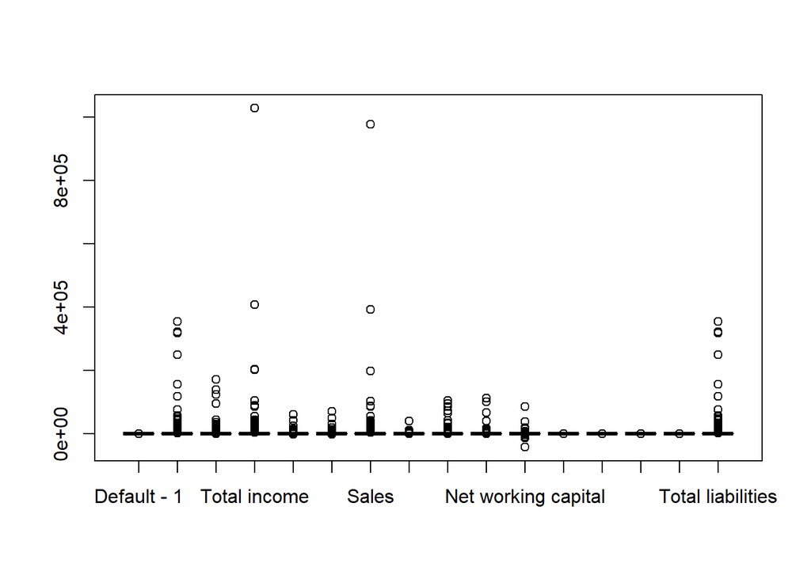

```r
## Outlier Treatment

# Check histogram and box plot for income and Sales as they have highest maximum amount

boxplot(Te_D1)
```

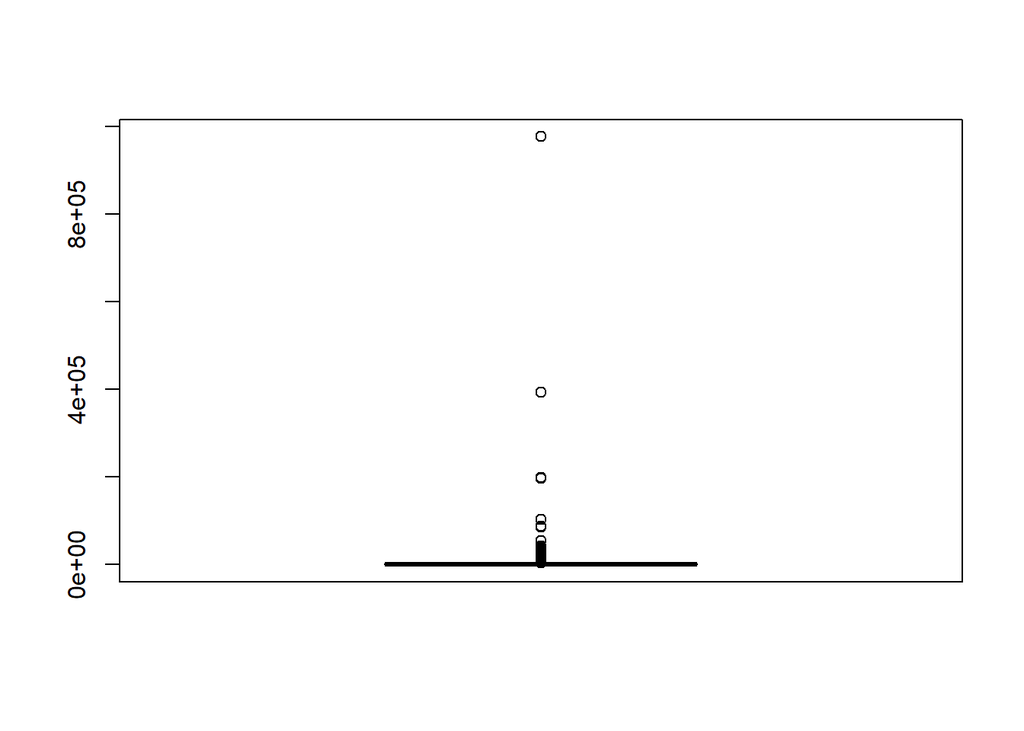

```r
boxplot(Te_D1$Sales)
boxplot(Te_D1$Sales)
```

```r
Te_D2=Te_D1[which(Te_D1$`Total assets`<50000),]
summary(Te_D2)
```

```
##  Default - 1  Total assets        Net worth        Total income
##  0:652       Min.   :    0.10   Min.   :    0.1   Min.   :    0.0
##  1: 54       1st Qu.:   90.05   1st Qu.:   32.9   1st Qu.:  109.1
##              Median :  344.00   Median :  117.3   Median :  511.2
##              Mean   : 1852.31   Mean   :  690.2   Mean   : 2184.4
##              3rd Qu.: 1163.75   3rd Qu.:  423.4   3rd Qu.: 1665.4
##              Max.   :47628.80   Max.   :28495.1   Max.   :89589.0
##                                                   NA's   :33
##  Profit after tax  Cash profit         Sales         Total capital
##  Min.   :-998.0   Min.   :-894.6   Min.   :    0.1   Min.   :   0.1
##  1st Qu.:   0.6   1st Qu.:   3.1   1st Qu.:  113.6   1st Qu.:  13.9
##  Median :   9.8   Median :  21.3   Median :  524.9   Median :  44.2
##  Mean   : 140.4   Mean   : 189.8   Mean   : 2160.2   Mean   : 167.7
##  3rd Qu.:  64.0   3rd Qu.: 114.1   3rd Qu.: 1665.7   3rd Qu.: 115.5
##  Max.   :7822.8   Max.   :9925.9   Max.   :87750.3   Max.   :7003.8
##  NA's   :23       NA's   :23       NA's   :46        NA's   :1
##    Borrowings      Current liabilities & provisions Net working capital
##  Min.   :    0.2   Min.   :    0.10                 Min.   :-12564.0
##  1st Qu.:   24.9   1st Qu.:   16.50                 1st Qu.:    -1.3
##  Median :  100.4   Median :   73.15                 Median :    19.2
##  Mean   :  620.2   Mean   :  487.95                 Mean   :   108.9
##  3rd Qu.:  364.3   3rd Qu.:  281.07                 3rd Qu.:    96.1
##  Max.   :20587.5   Max.   :17756.80                 Max.   : 16213.6
##  NA's   :65        NA's   :14                       NA's   :5
##  Quick ratio (times) Current ratio (times) Debt to equity ratio (times)
##  Min.   :  0.000     Min.   :  0.000       Min.   :  0.0000
##  1st Qu.:  0.410     1st Qu.:  0.920       1st Qu.:  0.2125
##  Median :  0.660     Median :  1.235       Median :  0.7950
##  Mean   :  1.982     Mean   :  2.901       Mean   :  3.3529
##  3rd Qu.:  1.020     3rd Qu.:  1.730       3rd Qu.:  1.6875
##  Max.   :341.000     Max.   :505.000       Max.   :341.1800
##  NA's   :12          NA's   :12
##  Cash to current liabilities (times) Total liabilities
##  Min.   :  0.0000                    Min.   :    0.10
##  1st Qu.:  0.0300                    1st Qu.:   90.05
##  Median :  0.0800                    Median :  344.00
##  Mean   :  0.7178                    Mean   : 1852.31
##  3rd Qu.:  0.1900                    3rd Qu.: 1163.75
##  Max.   :165.0000                    Max.   :47628.80
##  NA's   :12
```

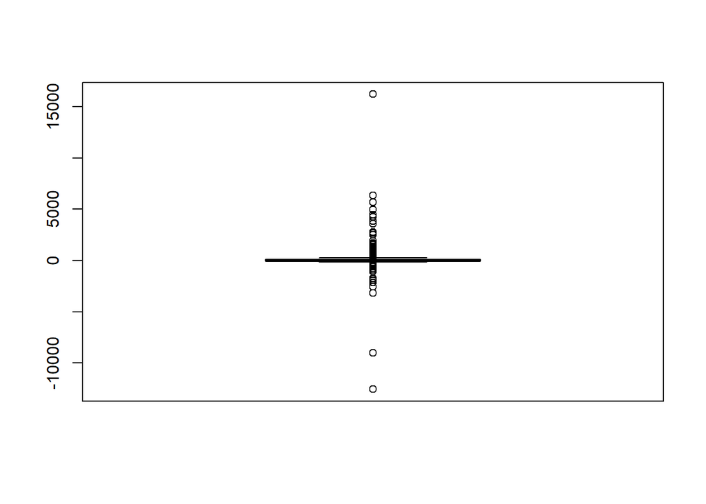

```r
boxplot(Te_D2$`Net working capital`)
```

```r
dim(Te_D2)
```

```
## [1] 706  16
```

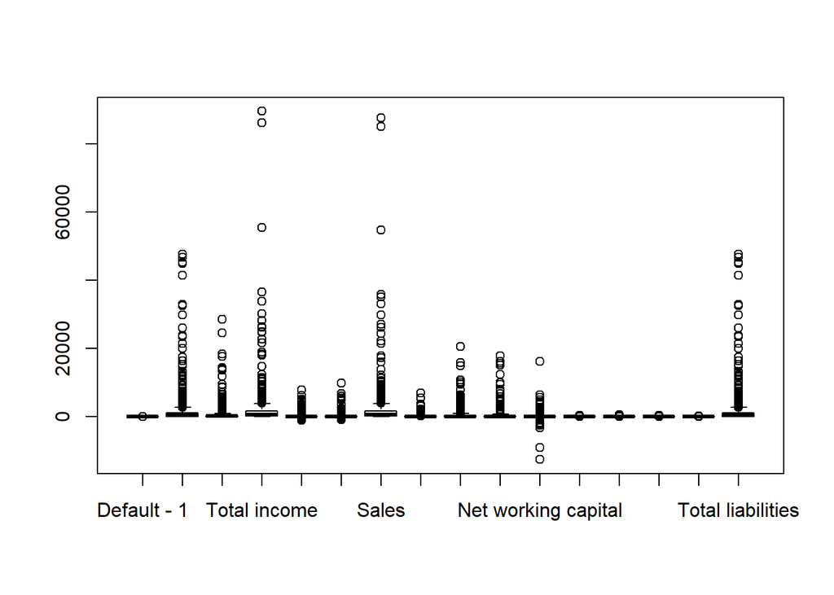

```r
boxplot(Te_D2)
```

```r
Te_D3=Te_D2[which(Te_D2$`Total income`<50000),]
summary(Te_D3)
```

```
##  Default - 1  Total assets       Net worth         Total income
##  0:625       Min.   :    0.7   Min.   :    0.20   Min.   :    0.0
##  1: 45       1st Qu.:  108.1   1st Qu.:   39.95   1st Qu.:  106.8
##              Median :  377.4   Median :  124.35   Median :  508.2
##              Mean   : 1757.4   Mean   :  655.49   Mean   : 1848.9
##              3rd Qu.: 1261.8   3rd Qu.:  448.00   3rd Qu.: 1625.9
##              Max.   :47628.8   Max.   :28495.10   Max.   :36623.3
##
##  Profit after tax  Cash profit           Sales         Total capital
##  Min.   :-998.0   Min.   :-894.600   Min.   :    0.1   Min.   :   0.4
##  1st Qu.:   0.8   1st Qu.:   3.425   1st Qu.:  112.0   1st Qu.:  15.0
##  Median :  10.2   Median :  22.050   Median :  510.1   Median :  46.7
##  Mean   : 123.9   Mean   : 167.413   Mean   : 1823.4   Mean   : 166.5
##  3rd Qu.:  64.0   3rd Qu.: 114.350   3rd Qu.: 1646.1   3rd Qu.: 119.5
##  Max.   :6289.3   Max.   :6801.200   Max.   :35926.7   Max.   :7003.8
##                                      NA's   :13        NA's   :1
##    Borrowings      Current liabilities & provisions Net working capital
##  Min.   :    0.2   Min.   :    0.1                  Min.   :-12564.0
##  1st Qu.:   29.6   1st Qu.:   18.4                  1st Qu.:    -1.0
##  Median :  107.5   Median :   77.8                  Median :    22.6
##  Mean   :  593.6   Mean   :  444.5                  Mean   :   115.6
##  3rd Qu.:  380.7   3rd Qu.:  287.1                  3rd Qu.:   100.7
##  Max.   :20587.5   Max.   :16288.1                  Max.   : 16213.6
##  NA's   :54        NA's   :3                        NA's   :1
##  Quick ratio (times) Current ratio (times) Debt to equity ratio (times)
##  Min.   :  0.000     Min.   :  0.000       Min.   :  0.000
##  1st Qu.:  0.425     1st Qu.:  0.945       1st Qu.:  0.230
##  Median :  0.670     Median :  1.240       Median :  0.810
##  Mean   :  1.981     Mean   :  2.916       Mean   :  2.915
##  3rd Qu.:  1.030     3rd Qu.:  1.740       3rd Qu.:  1.680
##  Max.   :341.000     Max.   :505.000       Max.   :341.180
##  NA's   :3           NA's   :3
##  Cash to current liabilities (times) Total liabilities
##  Min.   :  0.0000                    Min.   :    0.7
##  1st Qu.:  0.0300                    1st Qu.:  108.1
##  Median :  0.0800                    Median :  377.4
##  Mean   :  0.7419                    Mean   : 1757.4
##  3rd Qu.:  0.1900                    3rd Qu.: 1261.8
##  Max.   :165.0000                    Max.   :47628.8
##  NA's   :3
```

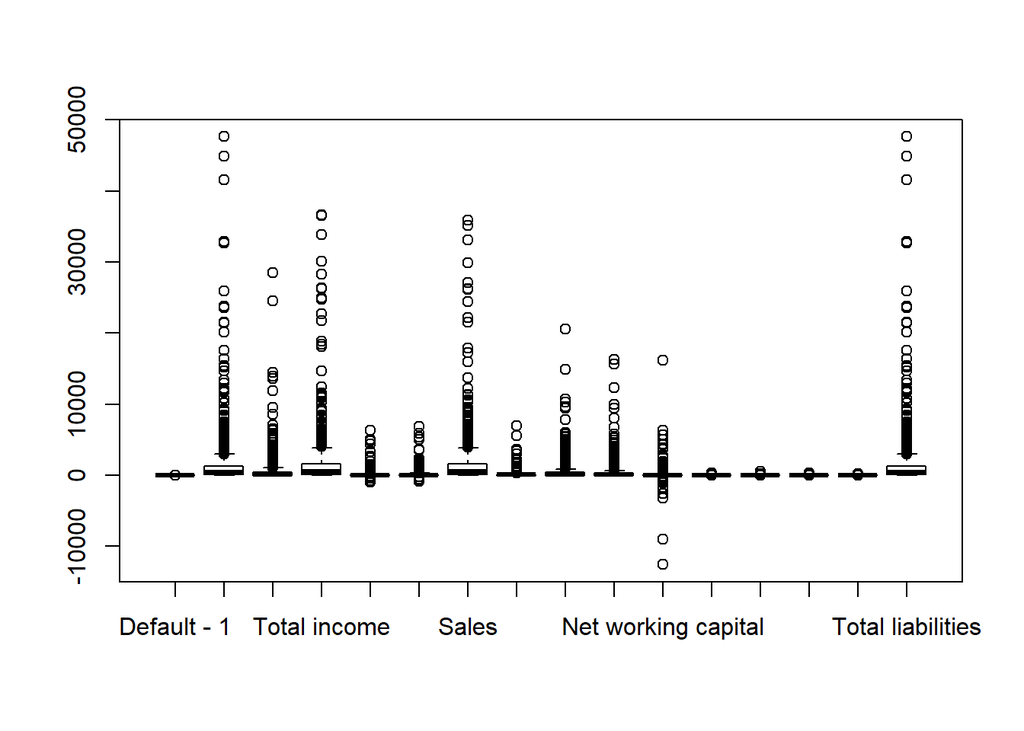

```r
boxplot(Te_D3)
```

```r
dim(Te_D3)
```

```
## [1] 670  16
```

```r
head(Te_D3[order(Te_D3$`Total income`,decreasing=TRUE),])
```

```
## # A tibble: 6 x 16
##   `Default - 1` `Total assets` `Net worth` `Total income` `Profit after t~
##   <fct>                  <dbl>       <dbl>          <dbl>            <dbl>
## 1 0                     32927.      14473          36623.            1487.
## 2 0                     32655.      13652.         36476             2669.
## 3 0                     13359.       1855.         33862.             437.
## 4 0                     23512.       3907.         30136.             170.
## 5 0                     44912.      28495.         28237.            4399.
## 6 0                      6883.       5177.         26362.            1327.
## # ... with 11 more variables: `Cash profit` <dbl>, Sales <dbl>, `Total
## #   capital` <dbl>, Borrowings <dbl>, `Current liabilities &
## #   provisions` <dbl>, `Net working capital` <dbl>, `Quick ratio
## #   (times)` <dbl>, `Current ratio (times)` <dbl>, `Debt to equity ratio
## #   (times)` <dbl>, `Cash to current liabilities (times)` <dbl>, `Total
## #   liabilities` <dbl>
```

```r
## Missing value Treatment - we can use basic imputation with mean or median or can use Mice or KNN imputation. we will go with knn as it will use the features of nearest neighbors to predict the missing value.

Te_D4=Te_D3[,-1]
Te_D4=data.frame(Te_D4)

Te_D5=knnImputation(Te_D4, k = 5)

colSums(is.na(Te_D5))
```

```
##                        Total.assets                           Net.worth
##                                   0                                   0
##                        Total.income                    Profit.after.tax
##                                   0                                   0
##                         Cash.profit                               Sales
##                                   0                                   0
##                       Total.capital                          Borrowings
##                                   0                                   0
##    Current.liabilities...provisions                 Net.working.capital
##                                   0                                   0
##                 Quick.ratio..times.               Current.ratio..times.
##                                   0                                   0
##        Debt.to.equity.ratio..times. Cash.to.current.liabilities..times.
##                                   0                                   0
##                   Total.liabilities
##                                   0
```

```r
summary(Te_D5)
```

```
##   Total.assets       Net.worth         Total.income     Profit.after.tax
##  Min.   :    0.7   Min.   :    0.20   Min.   :    0.0   Min.   :-998.0
##  1st Qu.:  108.1   1st Qu.:   39.95   1st Qu.:  106.8   1st Qu.:   0.8
##  Median :  377.4   Median :  124.35   Median :  508.2   Median :  10.2
##  Mean   : 1757.4   Mean   :  655.49   Mean   : 1848.9   Mean   : 123.9
##  3rd Qu.: 1261.8   3rd Qu.:  448.00   3rd Qu.: 1625.9   3rd Qu.:  64.0
##  Max.   :47628.8   Max.   :28495.10   Max.   :36623.3   Max.   :6289.3
##   Cash.profit           Sales         Total.capital      Borrowings
##  Min.   :-894.600   Min.   :    0.1   Min.   :   0.4   Min.   :    0.20
##  1st Qu.:   3.425   1st Qu.:  104.2   1st Qu.:  15.0   1st Qu.:   24.60
##  Median :  22.050   Median :  498.7   Median :  46.9   Median :   97.95
##  Mean   : 167.413   Mean   : 1789.9   Mean   : 166.3   Mean   :  573.06
##  3rd Qu.: 114.350   3rd Qu.: 1603.6   3rd Qu.: 119.0   3rd Qu.:  352.10
##  Max.   :6801.200   Max.   :35926.7   Max.   :7003.8   Max.   :20587.50
##  Current.liabilities...provisions Net.working.capital Quick.ratio..times.
##  Min.   :    0.10                 Min.   :-12564.00   Min.   :  0.0000
##  1st Qu.:   18.32                 1st Qu.:    -1.00   1st Qu.:  0.4225
##  Median :   76.40                 Median :    22.55   Median :  0.6700
##  Mean   :  442.54                 Mean   :   115.39   Mean   :  1.9783
##  3rd Qu.:  286.10                 3rd Qu.:   100.42   3rd Qu.:  1.0375
##  Max.   :16288.10                 Max.   : 16213.60   Max.   :341.0000
##  Current.ratio..times. Debt.to.equity.ratio..times.
##  Min.   :  0.000       Min.   :  0.000
##  1st Qu.:  0.950       1st Qu.:  0.230
##  Median :  1.240       Median :  0.810
##  Mean   :  2.920       Mean   :  2.915
##  3rd Qu.:  1.748       3rd Qu.:  1.680
##  Max.   :505.000       Max.   :341.180
##  Cash.to.current.liabilities..times. Total.liabilities
##  Min.   :  0.000                     Min.   :    0.7
##  1st Qu.:  0.030                     1st Qu.:  108.1
##  Median :  0.080                     Median :  377.4
##  Mean   :  0.741                     Mean   : 1757.4
##  3rd Qu.:  0.190                     3rd Qu.: 1261.8
##  Max.   :165.000                     Max.   :47628.8
```

```r
Test_Data=Te_D5



## Creation of new variables

## Profitability

# 1 . Return on Asset

Test_Data$ReturnonAsset=Test_Data$Total.income/Test_Data$Total.assets


# 2. Return on Equity

Test_Data$ReturnonEquity=Test_Data$Profit.after.tax/Test_Data$Net.worth



## Leverage

# 1. Debt to Equity ratio - This ratio already given as part of dataset

# 2. Debt to Capital ratio

Test_Data$DebttoCapital=Test_Data$Borrowings/Test_Data$Total.capital


## Liquidity Ratio

# 1. Current Ratio - given as part of dataset
# 2. Quick Ratio - given as part of dataset
# 3. Cash ratio - given as part of dataset


## Company Size Ratio

# 1. Income to Sales Ratio

Test_Data$Incometosales=Test_Data$Total.income/Test_Data$Sales


# 2. Profit to Sales Ratio

Test_Data$ProfittoSales=Test_Data$Profit.after.tax/Test_Data$Sales

# 3. Profit to Income Ratio

Test_Data$ProfittoIncome=Test_Data$Profit.after.tax/Test_Data$Total.income
Test_Data$ProfittoIncome[is.na(Test_Data$ProfittoIncome)]=median(Test_Data$ProfittoIncome,na.rm = T)


Test_Data=cbind(Test_Data,Te_D3[,1])

dim(Test_Data)
```

```
## [1] 670  22
```

```r
## EDA for Test Data

# Observations

# 1. Defaulting companies loses profit by 9 unit per 100 units and non defaulting companies earn profit by 3 units per 100 units of income.


summary(Te_D$`PAT as % of total income`[Te_D$`Default - 1`==0])
```

```
##     Min.  1st Qu.   Median     Mean  3rd Qu.     Max.     NA's
## -9700.00     0.73     2.78   -15.47     7.32   100.00        8
```

```r
summary(Te_D$`PAT as % of total income`[Te_D$`Default - 1`==1])
```

```
##      Min.   1st Qu.    Median      Mean   3rd Qu.      Max.      NA's
## -2600.000   -35.240    -9.140  -135.220    -0.035    70.970         3
```

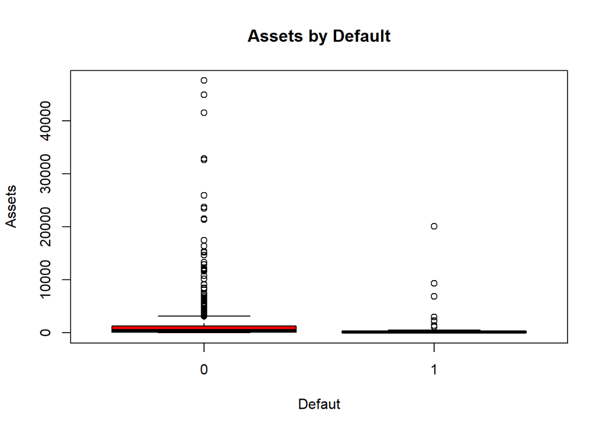

```r
boxplot(Te_D3$`Total assets`~Te_D3$`Default - 1`, xlab="Defaut",
        ylab="Assets",main="Assets by Default",col=c("Red","Green"))
```

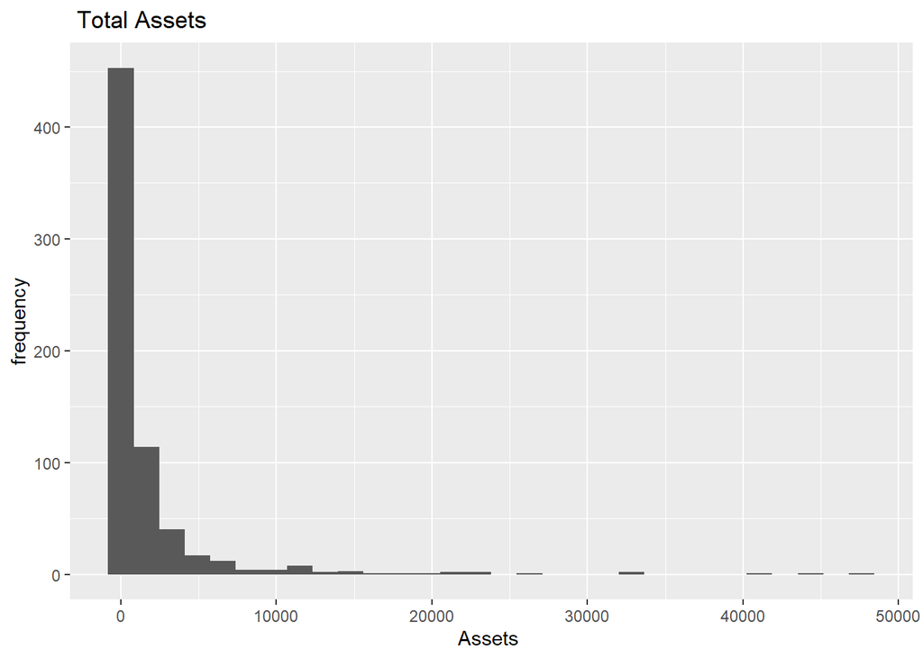

```r
# Numerical

qplot(Test_Data$Total.assets, data = Test_Data, main=" Total Assets ", xlab = "Assets ", ylab = "frequency")
```